# Heartbeat evoked Potential in FND

# 2) Clinical Supplements

## 2.1 Clinical Commorbidities

```r
# Select the relevant columns and include the calculated duration
Data.t <- dplyr::select(df, c("group", "pain_medication", "psychotropic_medication", "sleep_medication", "other_medication", "ADS_ADD", "psychiatric_disorder", "hormonal_dysfunction", "other_diagnosis", "contraception", "menopause", "mc_regularity"))

Data.t <- Data.t  %>%
  mutate(group = factor(group, levels = c("0", "1"), labels = c("HC", "FND")))

tbl2 <- Data.t %>%
  tbl_summary(
    by = group,
    missing = "no",
    statistic = list(
      pain_medication = "{n} ({p}%)",
      psychotropic_medication = "{n} ({p}%)",
      sleep_medication = "{n} ({p}%)",
      other_medication = "{n} ({p}%)",
      ADS_ADD = "{n} ({p}%)",
      psychiatric_disorder = "{n} ({p}%)",
      hormonal_dysfunction = "{n} ({p}%)",
      other_diagnosis = "{n} ({p}%)",
      contraception = "{n} ({p}%)",
      menopause = "{n} ({p}%)",
      mc_regularity = "{n} ({p}%)"
    ),
    label = list(
      pain_medication = "Intake of Pain Medication [yes]",
      psychotropic_medication = "Intake of Psychotropic Medication [yes]",
      sleep_medication = "Intake of Sleep Medication [yes]",
      other_medication = "Intake of Other Medication [yes]",
      ADS_ADD = "Comorbidity of ADS or AD(H)D [yes]",
      psychiatric_disorder = "Comorbidity of Psychiatric Disorder [yes]",
      hormonal_dysfunction = "Comorbidity of Hormonal Dysfunction [yes]",
      other_diagnosis = "Comorbidity of other Diagnosis [yes]",
      contraception = "Intake of Hormonal Contraception [yes]",
      menopause = "in Menopause [yes]",
      mc_regularity = "Regular, natural cycle [yes]"
    )
  ) %>%
  modify_header(list(label ~ "**Variable**")) %>%
  modify_caption("**Clinical Characteristics**") %>%
  modify_spanning_header(c("stat_1", "stat_2") ~ "**Group**") %>%
  add_p(test = everything() ~ "fisher.test") %>%
  add_overall(last = FALSE)

tbl2
```

**Clinical Characteristics**

| **Variable** | **Overall**, N = 88<sup>1</sup> | **Group** **HC**, N = 48<sup>1</sup> | **Group** **FND**, N = 40<sup>1</sup> | **p-value**<sup>2</sup> |  |
| --- | --- | --- | --- | --- | --- |
| Intake of Pain Medication [yes] | 15 (17%) | 3 (6.4%) | 12 (30%) |  | 0.005 |
| Intake of Psychotropic Medication [yes] | 19 (22%) | 2 (4.3%) | 17 (43%) | <0.001 |  |
| Intake of Sleep Medication [yes] | 8 (9.1%) | 0 (0%) | 8 (20%) | 0.001 |  |
| Intake of Other Medication [yes] | 20 (23%) | 7 (15%) | 13 (33%) | 0.072 |  |
| Comorbidity of ADS or AD(H)D [yes] | 5 (5.7%) | 1 (2.1%) | 4 (10%) | 0.2 |  |
| Comorbidity of Psychiatric Disorder [yes] | 14 (16%) | 3 (6.3%) | 11 (28%) | 0.009 |  |
| Comorbidity of Hormonal Dysfunction [yes] | 3 (3.4%) | 1 (2.1%) | 2 (5.0%) | 0.6 |  |
| Comorbidity of other Diagnosis [yes] | 12 (14%) | 3 (6.3%) | 9 (23%) | 0.033 |  |
| Intake of Hormonal Contraception [yes] |  |  |  | 0.033 |  |
| 0 | 76 (86%) | 45 (94%) | 31 (78%) |  |  |
| 1 | 12 (14%) | 3 (6.3%) | 9 (23%) |  |  |
| in Menopause [yes] |  |  |  | 0.7 |  |
| 0 | 77 (88%) | 41 (85%) | 36 (90%) |  |  |
| 1 | 11 (13%) | 7 (15%) | 4 (10%) |  |  |
| Regular, natural cycle [yes] |  |  |  | 0.6 |  |
| 0 | 5 (13%) | 4 (16%) | 1 (6.7%) |  |  |
| 1 | 35 (88%) | 21 (84%) | 14 (93%) |  |  |

<sup>1</sup> n (%)  
<sup>2</sup> Fisher’s exact test

```r
  # save table
    tbl2_df <- tbl2 %>% as_tibble()
    write_xlsx(tbl1_df, "2.1_Table_clinical_characteristics.xlsx")

Data.t <- dplyr::select(df_female, c("group", "contraception", "menopause", "mc_regularity"))

Data.t <- Data.t  %>%
  mutate(group = factor(group, levels = c("0", "1"), labels = c("HC", "FND")))

tbl2.2 <- Data.t %>%
  tbl_summary(
    by = group,
    missing = "no",
    statistic = list(
      contraception = "{n} ({p}%)",
      menopause = "{n} ({p}%)",
      mc_regularity = "{n} ({p}%)" ),
    label = list(
      contraception = "Intake of Hormonal Contraception [yes]",
      menopause = "in Menopause [yes]",
      mc_regularity = "Regular, natural cycle [yes]") ) %>%
  modify_header(list(label ~ "**Variable**")) %>%
  modify_caption("**Clinical Characteristics**") %>%
  modify_spanning_header(c("stat_1", "stat_2") ~ "**Group**") %>%
  add_p(test = everything() ~ "fisher.test") %>%
  add_overall(last = FALSE)

tbl2.2
```

**Clinical Characteristics**

| **Variable** | **Overall**, N = 65<sup>1</sup> | **Group** **HC**, N = 35<sup>1</sup> | **Group** **FND**, N = 30<sup>1</sup> | **p-value**<sup>2</sup> |  |
| --- | --- | --- | --- | --- | --- |
| Intake of Hormonal Contraception [yes] |  |  |  |  | 0.051 |
| 0 | 53 (82%) | 32 (91%) | 21 (70%) |  |  |
| 1 | 12 (18%) | 3 (8.6%) | 9 (30%) |  |  |
| in Menopause [yes] |  |  |  | 0.5 |  |
| 0 | 54 (83%) | 28 (80%) | 26 (87%) |  |  |
| 1 | 11 (17%) | 7 (20%) | 4 (13%) |  |  |
| Regular, natural cycle [yes] |  |  |  | 0.6 |  |
| 0 | 5 (13%) | 4 (16%) | 1 (6.7%) |  |  |
| 1 | 35 (88%) | 21 (84%) | 14 (93%) |  |  |

<sup>1</sup> n (%)  
<sup>2</sup> Fisher’s exact test

```r
  # save table
    tbl2_df <- tbl2.2 %>% as_tibble()
    write_xlsx(tbl1_df, "2.1_Table_clinical_characteristics_female.xlsx")
```

## 2.2 FND subtypes

```r
# create variable of duation of months
library(gtsummary)
library(dplyr)

# Select relevant columns from df_tbl
Data.t <- select(df_FND, c("sex", "diagnosis", "fds", "motor", "weakness", "sensory", "pppd", "cognitive"))

# Create the summary table
tbl3 <- Data.t %>%
  tbl_summary(
    by = sex,
    missing = "no",
    statistic = list(
      fds = "{n} ({p})",
      motor = "{n} ({p})",
      weakness = "{n} ({p})",
      sensory = "{n} ({p})",
      pppd = "{n} ({p})",
      cognitive = "{n} ({p})"),
    digits = list(duration_months = 1,fds = 1,motor = 1,weakness = 1,sensory = 1,pppd = 1,cognitive = 1),
    label = list(
      sex = "Sex",
      fds = "Functional Dissociative Seizures [yes]",
      motor = "motor + symptoms [yes]",
      weakness = "motor - symptoms [yes]",
      sensory = "sensory symptoms [yes]",
      pppd = "dizziness (PPPD) [yes]",
      cognitive = "cognitive symptoms [yes]"
    )
  ) %>%
  modify_header(list(label ~ "**Variable**")) %>%
  modify_caption("**Clinical Characteristics**") %>%
  modify_spanning_header(c("stat_1", "stat_2") ~ "**Group**") %>%
  add_overall(last = FALSE)

# Print the summary table
tbl3
```

**Clinical Characteristics**

| **Variable** | **Overall**, N = 40<sup>1</sup> | **Group** **1**, N = 30<sup>1</sup> | **Group** **2**, N = 10<sup>1</sup> |
| --- | --- | --- | --- |
| diagnosis |  |  |  |
| 1 | 3 (7.5%) | 3 (10%) | 0 (0%) |
| 2 | 9 (23%) | 5 (17%) | 4 (40%) |
| 3 | 7 (18%) | 5 (17%) | 2 (20%) |
| 4 | 2 (5.0%) | 2 (6.7%) | 0 (0%) |
| 5 | 19 (48%) | 15 (50%) | 4 (40%) |
| Functional Dissociative Seizures [yes] | 7.0 (17.5) | 7.0 (23.3) | 0.0 (0.0) |
| motor + symptoms [yes] | 17.0 (42.5) | 12.0 (40.0) | 5.0 (50.0) |
| motor - symptoms [yes] | 27.0 (67.5) | 19.0 (63.3) | 8.0 (80.0) |
| sensory symptoms [yes] | 20.0 (50.0) | 16.0 (53.3) | 4.0 (40.0) |
| dizziness (PPPD) [yes] | 2.0 (5.0) | 2.0 (6.7) | 0.0 (0.0) |
| cognitive symptoms [yes] | 4.0 (10.0) | 4.0 (13.3) | 0.0 (0.0) |

<sup>1</sup> n (%)

```r
  # save table
    tbl2_df <- tbl3 %>% as_tibble()
    write_xlsx(tbl1_df, "2.2_Table_FNDsubtypes.xlsx")

summary(df_FND$duration_months)
```

```
   Min. 1st Qu.  Median    Mean 3rd Qu.    Max.
  12.00   34.00   55.00   76.17   77.75  305.00
```

```r
sd(df_FND$duration_months)
```

```
[1] 67.48139
```

```r
## additional table for diagnosis (instead of symptoms)
df_FND$diagnosis
```

```
 [1] 5 1 2 5 2 2 2 5 5 3 5 5 5 3 5 5 5 5 2 5 3 5 1 3 4 1 2 2 3 2 5 5 5 5 5 3 2 5
[39] 4 3
```

```r
# Define diagnosis labels
diagnosis_labels <- c(
  "44.5 Functional/Dissociative Seizures",
  "44.4 motor FND",
  "44.4 motor FND",
  "44.6 sensory FND",
  "44.7 mixed FND")

# Recode diagnosis
df_FND$diagnosis <- dplyr::case_when(df_FND$diagnosis == 1 ~ diagnosis_labels[1],
  df_FND$diagnosis %in% c(2, 3) ~ diagnosis_labels[2],
  df_FND$diagnosis == 4 ~ diagnosis_labels[4],
  df_FND$diagnosis == 5 ~ diagnosis_labels[5],
  TRUE ~ "Other")

# Convert to factors
df_FND$diagnosis <- factor(df_FND$diagnosis)
df_FND$sex <- factor(df_FND$sex, levels = c(1, 2), labels = c("Female", "Male"))

# Create contingency table
table_diagnosis <- table(df_FND$diagnosis, df_FND$sex)
print(table_diagnosis)
```

```
                                        Female Male
  44.4 motor FND                            10    6
  44.5 Functional/Dissociative Seizures      3    0
  44.6 sensory FND                           2    0
  44.7 mixed FND                            15    4
```

```r
# Convert to data frame
df_table <- as.data.frame.matrix(table_diagnosis)
df_table <- cbind(Diagnosis = rownames(df_table), df_table)
writexl::write_xlsx(df_table, "2.2_diagnosis_FND.xlsx")
```

# 3) HBT: group differences

```r
# non paramatric wilcox test for NOT normally distributed data
shapiro.test(df$hbt_accuracy_mean) # NOT normally distributed
```

```
    Shapiro-Wilk normality test

data:  df$hbt_accuracy_mean
W = 0.95803, p-value = 0.006147
```

```r
res<-wilcox.test(df$hbt_accuracy_mean[df$group=="1"], df$hbt_accuracy_mean[df$group=="0"])
res #  p-value = 0.06046
```

```
    Wilcoxon rank sum test with continuity correction

data:  df$hbt_accuracy_mean[df$group == "1"] and df$hbt_accuracy_mean[df$group == "0"]
W = 735.5, p-value = 0.06046
alternative hypothesis: true location shift is not equal to 0
```

```r
cohens_d_hbt_mean <- calculate_cohens_d(df, "hbt_accuracy_mean", "group", 1, 0) # group 1=FND, group=0 HC
print(cohens_d_hbt_mean) #-0.4293561
```

```
[1] -0.4293561
```

```r
shapiro.test(df$hbt_change_accuracy) # NOT normally distributed
```

```
    Shapiro-Wilk normality test

data:  df$hbt_change_accuracy
W = 0.96231, p-value = 0.01171
```

```r
res<-wilcox.test(df$hbt_change_accuracy[df$group=="1"], df$hbt_change_accuracy[df$group=="0"])
res  # no sig difference between groups
```

```
    Wilcoxon rank sum test with continuity correction

data:  df$hbt_change_accuracy[df$group == "1"] and df$hbt_change_accuracy[df$group == "0"]
W = 999.5, p-value = 0.7438
alternative hypothesis: true location shift is not equal to 0
```

```r
shapiro.test(df$hbt_confidence_mean) # NOT normally distributed
```

```
    Shapiro-Wilk normality test

data:  df$hbt_confidence_mean
W = 0.91482, p-value = 2.425e-05
```

```r
res<-wilcox.test(df$hbt_confidence_mean[df$group=="1"], df$hbt_confidence_mean[df$group=="0"])
res # no sig difference between groups
```

```
    Wilcoxon rank sum test with continuity correction

data:  df$hbt_confidence_mean[df$group == "1"] and df$hbt_confidence_mean[df$group == "0"]
W = 858, p-value = 0.3947
alternative hypothesis: true location shift is not equal to 0
```

```r
shapiro.test(df$hbt_change_confidence) #  normally distributed
```

```
    Shapiro-Wilk normality test

data:  df$hbt_change_confidence
W = 0.98703, p-value = 0.5332
```

```r
res<-t.test(df$hbt_change_confidence[df$group=="1"], df$hbt_change_confidence[df$group=="0"])
res  # no sig difference between groups
```

```
    Welch Two Sample t-test

data:  df$hbt_change_confidence[df$group == "1"] and df$hbt_change_confidence[df$group == "0"]
t = -0.53665, df = 85.451, p-value = 0.5929
alternative hypothesis: true difference in means is not equal to 0
95 percent confidence interval:
 -10.866457   6.247012
sample estimates:
mean of x mean of y
 1.016667  3.326389
```

```r
shapiro.test(df$hbt_intensity_mean) # NOT normally distributed
```

```
    Shapiro-Wilk normality test

data:  df$hbt_intensity_mean
W = 0.96339, p-value = 0.0138
```

```r
res<-wilcox.test(df$hbt_intensity_mean[df$group=="1"], df$hbt_intensity_mean[df$group=="0"])
res# no sig difference between groups
```

```
    Wilcoxon rank sum test with continuity correction

data:  df$hbt_intensity_mean[df$group == "1"] and df$hbt_intensity_mean[df$group == "0"]
W = 860, p-value = 0.4043
alternative hypothesis: true location shift is not equal to 0
```

## 3.1 Summary Table

```r
Data.t <- select(df_tbl, c("group", "hbt_accuracy_mean", "hbt_confidence_mean", "hbt_intensity_mean", "hbt_easiness_mean", "hbt_change_accuracy", "hbt_change_confidence", "maia_total", "traitPE_maiaHBT", "ias", "traitPE_iasHBT"))
library(gtsummary)
tbl_hbt <- Data.t %>%
  tbl_summary(
    by = group,
    missing = "no",
    statistic = list(
      hbt_accuracy_mean = "{median} ({IQR})",
      hbt_confidence_mean = "{median} ({IQR})",
      hbt_intensity_mean = "{median} ({IQR})",
      hbt_easiness_mean = "{median} ({IQR})",
      hbt_change_accuracy = "{median} ({IQR})",
      hbt_change_confidence = "{median} ({IQR})",
      maia_total = "{median} ({IQR})",
      traitPE_maiaHBT = "{median} ({IQR})",
      ias = "{median} ({IQR})",
      traitPE_iasHBT = "{median} ({IQR})"    ),
    digits = list(hbt_accuracy_mean = 1, hbt_confidence_mean = 1, hbt_intensity_mean = 1, hbt_easiness_mean = 1,
                  hbt_change_accuracy = 1, hbt_change_confidence = 1, hep_focus = 1, hep_difficulty = 1, hep_intensity = 1,
                  maia_total = 1, traitPE_maiaHBT = 1,ias = 1, traitPE_iasHBT = 1),
    label = list(hbt_accuracy_mean = "HBT accuracy",
                 hbt_confidence_mean= "HBT confidence",
                 hbt_intensity_mean= "HBT intensity",
                 hbt_easiness_mean= "HBT easiness",
                 hbt_change_accuracy= "HBT change in accuracy",
                 hbt_change_confidence = "HBT change in confidence",
                 maia_total = "Interoceptive Awareness (MAIA)",
                 traitPE_maiaHBT= "Trait-Prediction-Error (MAIA-HBT)",
                 ias= "Interoceptive Accuracy Self-Report (IAS)",
                 traitPE_iasHBT = "Trait-Prediction-Error (IAS-HBT)")
  ) %>%
  modify_header(list(label ~ "**Variable**")) %>%
  modify_caption("**Interoception Overview**") %>%
  modify_spanning_header(c("stat_1", "stat_2") ~ "**Group**") %>%
  add_p(test = everything() ~ "wilcox.test") %>%
  add_overall(last = FALSE)

tbl_hbt
```

**Interoception Overview**

| **Variable** | **Overall**, N = 88<sup>1</sup> | **Group** **HC**, N = 48<sup>1</sup> | **Group** **FND**, N = 40<sup>1</sup> | **p-value**<sup>2</sup> |  |
| --- | --- | --- | --- | --- | --- |
| HBT accuracy | 0.5 (0.5) | 0.5 (0.5) | 0.4 (0.4) |  | 0.060 |
| HBT confidence | 20.6 (36.5) | 21.7 (34.7) | 19.8 (33.9) | 0.4 |  |
| HBT intensity | 25.0 (22.8) | 25.0 (26.3) | 24.2 (23.1) | 0.4 |  |
| HBT easiness | 23.8 (26.7) | 25.7 (25.0) | 20.7 (28.0) | 0.3 |  |
| HBT change in accuracy | 0.0 (0.3) | 0.0 (0.2) | 0.0 (0.2) | 0.7 |  |
| HBT change in confidence | 0.0 (26.3) | 3.2 (28.3) | 0.0 (23.8) | 0.5 |  |
| Interoceptive Awareness (MAIA) | 23.1 (7.5) | 24.8 (4.8) | 19.9 (8.2) | 0.001 |  |
| Trait-Prediction-Error (MAIA-HBT) | -0.1 (1.7) | 0.0 (1.4) | -0.1 (1.5) | 0.3 |  |
| Interoceptive Accuracy Self-Report (IAS) | 85.0 (19.0) | 89.0 (14.3) | 79.5 (27.0) | 0.020 |  |
| Trait-Prediction-Error (IAS-HBT) | 0.0 (1.6) | 0.0 (1.6) | -0.2 (1.8) | 0.5 |  |

<sup>1</sup> Median (IQR)  
<sup>2</sup> Wilcoxon rank sum test; Wilcoxon rank sum exact test

```r
  # Save as png table
  gt_table <- as_gt(tbl_hbt) # convert to gt table
  output_path <- file.path("3.1_Table_HBT.png")
  gt::gtsave(gt_table, filename = output_path)

  # Save as xlsx table
  df_table <- as_tibble(tbl_hbt)
  output_path <- file.path("3.1_Table_HBT.xlsx")
  write_xlsx(df_table, path = output_path)
```

## 3.2 Change across Condition

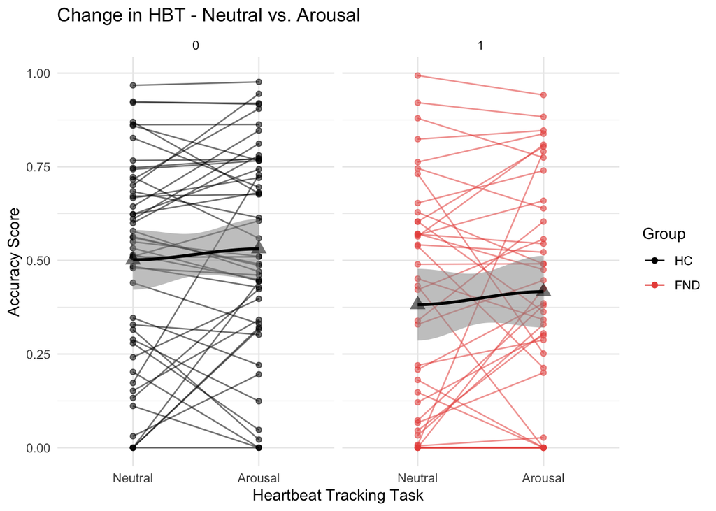

```r
hbt <- dplyr::select(df, pcode, group, hbt_accuracy_neutral, hbt_accuracy_arousal)

# Make data long
library(tidyverse)
library(dplyr)
long_data <- gather(hbt, key = "HBT", value = "score", -pcode, -group) # make data set long
long_data$HBT<-plyr::revalue(long_data$HBT, c("hbt_accuracy_neutral"="Neutral","hbt_accuracy_arousal" ="Arousal"))
long_data$HBT<-as.factor(long_data$HBT)
long_data$HBT <- factor(long_data$HBT, levels = rev(levels(long_data$HBT)))

# faceted, separate graphs per condition
library(ggplot2)
HBTplot <- ggplot(long_data, aes(x = HBT, y = score, group = pcode, color = group, alpha = 0.8)) +
  geom_line() +
  geom_point() +
  facet_grid(. ~ group) + # Zum nach Gruppe unterteilen
  labs(title = "Change in HBT - Neutral vs. Arousal",
       x = "Heartbeat Tracking Task",
       y = "Accuracy Score",
       color = "Group") +
  theme_minimal() +
  stat_smooth(aes(group = group, color = group), color = "black") + # Brauchts für die CI
  stat_summary(aes(group = group, color = group), geom = "point", fun = mean, shape = 17, size = 3.5, color = "black")+ # zum mean machen (die dickere linie, kannst du auch noch dicker machen)
  scale_alpha(guide = 'none') +
  scale_color_manual(values = c("black", "#E95248"), labels = c("HC", "FND"))
HBTplot
```

```r
    pdf("3.2_Plot_HBTchange_acc.pdf")
    HBTplot
    dev.off()
```

```r
# statistics:
res_FND<-wilcox.test(df$hbt_accuracy_neutral[df$group=="1"], df$hbt_accuracy_neutral[df$group=="1"], paired = TRUE)
res_FND #  no sig difference between condition in FND
```

```
    Wilcoxon signed rank test with continuity correction

data:  df$hbt_accuracy_neutral[df$group == "1"] and df$hbt_accuracy_neutral[df$group == "1"]
V = 0, p-value = NA
alternative hypothesis: true location shift is not equal to 0
```

```r
res_HC<-wilcox.test(df$hbt_accuracy_arousal[df$group=="0"], df$hbt_accuracy_arousal[df$group=="0"], paired = TRUE)#  no sig difference between condition in HC
res_HC
```

```
    Wilcoxon signed rank test with continuity correction

data:  df$hbt_accuracy_arousal[df$group == "0"] and df$hbt_accuracy_arousal[df$group == "0"]
V = 0, p-value = NA
alternative hypothesis: true location shift is not equal to 0
```

```r
  # Capture stat output as text
  res_FND_text <- capture.output(print(res_FND))
  res_HC_text <- capture.output(print(res_HC))
  results_text <- c("### Wilcoxon Test: FND Group ###", res_FND_text,
                  "", "### Wilcoxon Test: HC Group ###", res_HC_text)
  writeLines(results_text, "3.2_stats_HBTchange_acc.txt")

# same thing for confidence
hbt_confidence <- dplyr::select(df, pcode, group, hbt_confidence_neutral, hbt_confidence_arousal)
long_data_confidence <- gather(hbt_confidence, key = "HBT", value = "score", -pcode, -group) # make data set long
long_data_confidence$HBT<-revalue(long_data_confidence$HBT, c("hbt_confidence_neutral"="Neutral","hbt_confidence_arousal" ="Arousal"))
long_data_confidence$HBT<-as.factor(long_data_confidence$HBT)
long_data_confidence$HBT <- factor(long_data_confidence$HBT, levels = rev(levels(long_data_confidence$HBT)))

HBTplot <- ggplot(long_data_confidence, aes(x = HBT, y = score, group = pcode, color = group, alpha = 0.8)) +
  geom_line() +
  geom_point() +
  facet_grid(. ~ group) +
  labs(title = "Change in HBT confidence - Neutral vs. Arousal",
       x = "Heartbeat Tracking Task",
       y = "confidence Score",
       color = "Group") +
  theme_minimal() +
  stat_smooth(aes(group = group, color = group), color = "black") + # Brauchts für die CI
  stat_summary(aes(group = group, color = group), geom = "point", fun = mean, shape = 17, size = 3.5, color = "black")+
  scale_alpha(guide = 'none')+
  scale_color_manual(values = c("black", "#E95248"), labels = c("HC", "FND")) # Custom labels for 0 and 1

    pdf("3.2_Plot_HBTchange_conf.pdf")
    HBTplot
    dev.off()
```

```r
# statistics:
res_FND<-wilcox.test(df$hbt_confidence_neutral[df$group=="1"], df$hbt_confidence_arousal[df$group=="1"], paired = TRUE)
res_FND #  no sig difference between condition in FND
```

```
    Wilcoxon signed rank test with continuity correction

data:  df$hbt_confidence_neutral[df$group == "1"] and df$hbt_confidence_arousal[df$group == "1"]
V = 303.5, p-value = 0.857
alternative hypothesis: true location shift is not equal to 0
```

```r
res_HC<-wilcox.test(df$hbt_confidence_neutral[df$group=="0"], df$hbt_confidence_arousal[df$group=="0"], paired = TRUE)#  no sig difference between condition in HC
res_HC
```

```
    Wilcoxon signed rank test with continuity correction

data:  df$hbt_confidence_neutral[df$group == "0"] and df$hbt_confidence_arousal[df$group == "0"]
V = 388, p-value = 0.2139
alternative hypothesis: true location shift is not equal to 0
```

```r
  # Capture stat output as text
  res_FND_text <- capture.output(print(res_FND))
  res_HC_text <- capture.output(print(res_HC))
  results_text <- c("### Wilcoxon Test: FND Group ###", res_FND_text,
                  "", "### Wilcoxon Test: HC Group ###", res_HC_text)
  writeLines(results_text, "3.2_stats_HBTchange_conf.txt")
```

# 4) HEP: debriefing questions (control analysis)

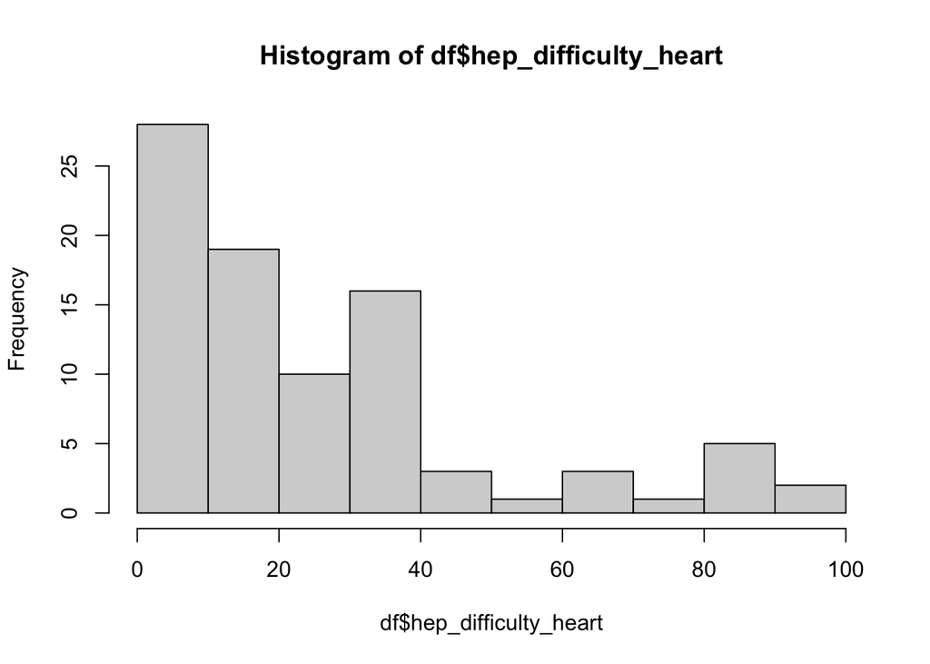

```r
hist(df$hep_difficulty_heart)
```

```r
shapiro.test(df$hep_difficulty_heart)  # NOT normally distributed with  p < 0.05
```

```
    Shapiro-Wilk normality test

data:  df$hep_difficulty_heart
W = 0.85192, p-value = 6.428e-08
```

```r
shapiro.test(df$hep_difficulty_heart[df$group == "1"]) # within patients hep difficulty heart is NOT normally distributed with  p < 0.05
```

```
    Shapiro-Wilk normality test

data:  df$hep_difficulty_heart[df$group == "1"]
W = 0.73596, p-value = 3.995e-07
```

```r
shapiro.test(df$hep_difficulty_heart[df$group == "0"]) # within controls hep difficulty heart is NOT normally distributed with  p < 0.05
```

```
    Shapiro-Wilk normality test

data:  df$hep_difficulty_heart[df$group == "0"]
W = 0.90556, p-value = 0.0009554
```

```r
summary(df$hep_difficulty_heart)
```

```
   Min. 1st Qu.  Median    Mean 3rd Qu.    Max.
   0.00    8.00   16.00   25.44   36.25   92.00
```

```r
summary(df_FND$hep_difficulty_heart)
```

```
   Min. 1st Qu.  Median    Mean 3rd Qu.    Max.
      0       0      12      19      23      91
```

```r
summary(df_HC$hep_difficulty_heart)
```

```
   Min. 1st Qu.  Median    Mean 3rd Qu.    Max.
   0.00   12.75   26.50   30.81   40.00   92.00
```

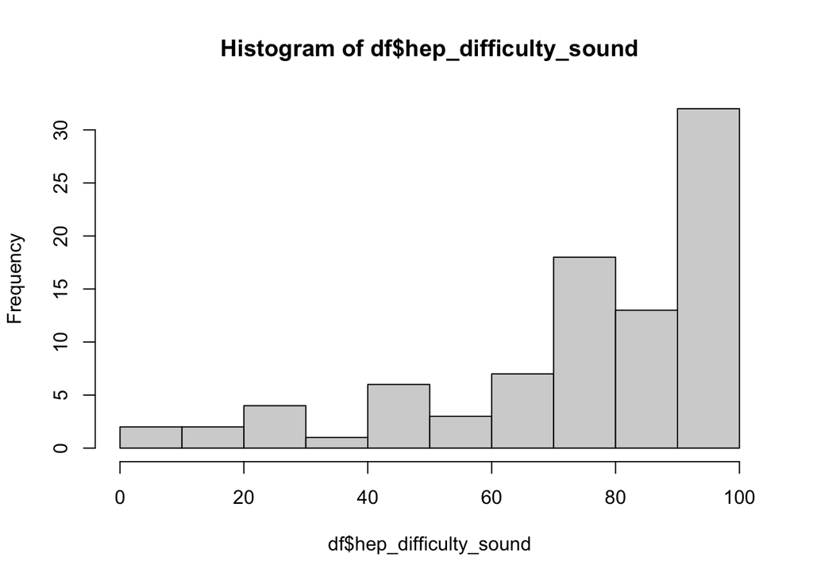

```r
hist(df$hep_difficulty_sound)
```

```r
shapiro.test(df$hep_difficulty_sound)  # NOT normally distributed with  p < 0.05
```

```
    Shapiro-Wilk normality test

data:  df$hep_difficulty_sound
W = 0.84681, p-value = 4.262e-08
```

```r
shapiro.test(df$hep_difficulty_sound[df$group == "1"]) # within patients hep difficulty sound is NOT normally distributed with  p < 0.05
```

```
    Shapiro-Wilk normality test

data:  df$hep_difficulty_sound[df$group == "1"]
W = 0.86116, p-value = 0.0001699
```

```r
shapiro.test(df$hep_difficulty_sound[df$group == "0"]) # within controls hep difficulty sound is NOT normally distributed with  p < 0.05
```

```
    Shapiro-Wilk normality test

data:  df$hep_difficulty_sound[df$group == "0"]
W = 0.8784, p-value = 0.0001355
```

```r
summary(df$hep_difficulty_sound)
```

```
   Min. 1st Qu.  Median    Mean 3rd Qu.    Max.
   0.00   68.75   81.50   76.15   95.25  100.00
```

```r
summary(df_FND$hep_difficulty_sound)
```

```
   Min. 1st Qu.  Median    Mean 3rd Qu.    Max.
   0.00   43.25   78.50   69.20   92.75  100.00
```

```r
summary(df_HC$hep_difficulty_sound)
```

```
   Min. 1st Qu.  Median    Mean 3rd Qu.    Max.
  22.00   70.50   88.00   81.94   96.00  100.00
```

```r
# Create an empty list to store p-values
test_results <- list()

# Function to compute Wilcoxon test and store p-values
store_p_value <- function(name, group1, group2, paired=FALSE) {
  test_results[[name]] <<- wilcox.test(group1, group2, paired=paired)$p.value}

# Between-group comparisons
store_p_value("hep_difficulty_heart (FND vs HC)", df$hep_difficulty_heart[df$group=="1"], df$hep_difficulty_heart[df$group=="0"])
store_p_value("hep_difficulty_sound (FND vs HC)", df$hep_difficulty_sound[df$group=="1"], df$hep_difficulty_sound[df$group=="0"])

# Within-group (paired) comparisons
store_p_value("hep_difficulty (FND: sound vs heart)", df_FND$hep_difficulty_sound, df_FND$hep_difficulty_heart, paired=TRUE)
store_p_value("hep_difficulty (HC: sound vs heart)", df_HC$hep_difficulty_sound, df_HC$hep_difficulty_heart, paired=TRUE)

# Between-group comparisons for focus
store_p_value("hep_focus_heart (FND vs HC)", df$hep_focus_heart[df$group=="1"], df$hep_focus_heart[df$group=="0"])
store_p_value("hep_focus_sound (FND vs HC)", df$hep_focus_sound[df$group=="1"], df$hep_focus_sound[df$group=="0"])

# Within-group (paired) comparisons for focus
store_p_value("hep_focus (FND: sound vs heart)", df_FND$hep_focus_sound, df_FND$hep_focus_heart, paired=TRUE)
store_p_value("hep_focus (HC: sound vs heart)", df_HC$hep_focus_sound, df_HC$hep_focus_heart, paired=TRUE)

# Between-group comparisons for intensity
store_p_value("hep_intensity_heart (FND vs HC)", df$hep_intensity_heart[df$group=="1"], df$hep_intensity_heart[df$group=="0"])
store_p_value("hep_intensity_sound (FND vs HC)", df$hep_intensity_sound[df$group=="1"], df$hep_intensity_sound[df$group=="0"])

# Within-group (paired) comparisons for intensity
store_p_value("hep_intensity (FND: sound vs heart)", df_FND$hep_intensity_sound, df_FND$hep_intensity_heart, paired=TRUE)
store_p_value("hep_intensity (HC: sound vs heart)", df_HC$hep_intensity_sound, df_HC$hep_intensity_heart, paired=TRUE)

# Convert list to dataframe
p_values_df <- data.frame(
  Comparison = names(test_results),
  p_value = unlist(test_results))

# Apply FDR correction
p_values_df$p_adj_fdr <- p.adjust(p_values_df$p_value, method = "fdr")

# Print results
print(p_values_df)
```

```
                                                               Comparison
hep_difficulty_heart (FND vs HC)         hep_difficulty_heart (FND vs HC)
hep_difficulty_sound (FND vs HC)         hep_difficulty_sound (FND vs HC)
hep_difficulty (FND: sound vs heart) hep_difficulty (FND: sound vs heart)
hep_difficulty (HC: sound vs heart)   hep_difficulty (HC: sound vs heart)
hep_focus_heart (FND vs HC)                   hep_focus_heart (FND vs HC)
hep_focus_sound (FND vs HC)                   hep_focus_sound (FND vs HC)
hep_focus (FND: sound vs heart)           hep_focus (FND: sound vs heart)
hep_focus (HC: sound vs heart)             hep_focus (HC: sound vs heart)
hep_intensity_heart (FND vs HC)           hep_intensity_heart (FND vs HC)
hep_intensity_sound (FND vs HC)           hep_intensity_sound (FND vs HC)
hep_intensity (FND: sound vs heart)   hep_intensity (FND: sound vs heart)
hep_intensity (HC: sound vs heart)     hep_intensity (HC: sound vs heart)
                                          p_value    p_adj_fdr
hep_difficulty_heart (FND vs HC)     2.251111e-03 3.859047e-03
hep_difficulty_sound (FND vs HC)     1.551194e-01 2.068258e-01
hep_difficulty (FND: sound vs heart) 8.059027e-07 1.611805e-06
hep_difficulty (HC: sound vs heart)  1.784113e-09 1.471925e-08
hep_focus_heart (FND vs HC)          3.104271e-01 3.725125e-01
hep_focus_sound (FND vs HC)          3.472073e-01 3.787715e-01
hep_focus (FND: sound vs heart)      1.226785e-07 2.944284e-07
hep_focus (HC: sound vs heart)       3.193299e-09 1.471925e-08
hep_intensity_heart (FND vs HC)      1.479344e-01 2.068258e-01
hep_intensity_sound (FND vs HC)      8.595558e-01 8.595558e-01
hep_intensity (FND: sound vs heart)  3.980827e-08 1.194248e-07
hep_intensity (HC: sound vs heart)   3.679812e-09 1.471925e-08
```

```r
  # Save as a text file
  write.table(p_values_df, "4_debriefing.txt", sep = "\t", row.names = FALSE, quote = FALSE)

# Calculating cohens d for diferent self-reported difficutly
cohens_d_difficulty_heart <- calculate_cohens_d(df, "hep_difficulty_heart", "group", 1, 0) # group 1=FND, group=0 HC
print(cohens_d_difficulty_heart)
```

```
[1] -0.4851511
```

## 4.1 Summary Table

```r
### Summary Table for debriefing questionnaire ---------------------------------------------
df_tbl <- df %>%
  mutate(group = factor(group, levels = c("0", "1"), labels = c("HC", "FND")))

Data.t <- select(df_tbl, c("group","hep_difficulty_heart", "hep_difficulty_sound", "hep_focus_heart", "hep_focus_sound", "hep_intensity_heart", "hep_intensity_sound"))
library(gtsummary)
library(gtsummary)
library(dplyr)

# Create the table summary
tbl_hep <- Data.t %>%
  tbl_summary(
    by = group, # Grouping by 'group'
    missing = "no",
    statistic = list(
      hep_difficulty_heart = "{median} ({IQR})",
      hep_difficulty_sound = "{median} ({IQR})",
      hep_focus_heart ="{median} ({IQR})",
      hep_focus_sound = "{median} ({IQR})",
      hep_intensity_heart = "{median} ({IQR})",
      hep_intensity_sound = "{median} ({IQR})" ),
    digits = list(hep_difficulty_heart = 1, hep_difficulty_sound = 1, hep_focus_heart = 1, hep_focus_sound = 1, hep_intensity_heart = 1, hep_intensity_sound = 1),
    label = list(
      hep_difficulty_heart = "Easiness to perceive Heartbeat",
      hep_difficulty_sound = "Easiness to perceive Sound",
      hep_focus_heart = "Ability to focus on Heartbeat",
      hep_focus_sound = "Ability to focus on Sound",
      hep_intensity_heart = "Intensity of perceived Heartbeat",
      hep_intensity_sound = "Intensity of perceived Sound") ) %>%
  modify_header(list(label ~ "**Variable**")) %>%
  modify_caption("**Control Question**") %>%
  modify_spanning_header(c("stat_1", "stat_2") ~ "**Group**") %>%
  add_p(
    test = list(
      hep_difficulty_heart = "wilcox.test",
      hep_difficulty_sound = "wilcox.test",
      hep_focus_heart = "wilcox.test",
      hep_focus_sound = "wilcox.test",
      hep_intensity_heart = "wilcox.test",
      hep_intensity_sound = "wilcox.test"  )) %>%
  add_overall(last = FALSE)

# Print the table
tbl_hep
```

**Control Question**

| **Variable** | **Overall**, N = 88<sup>1</sup> | **Group** **HC**, N = 48<sup>1</sup> | **Group** **FND**, N = 40<sup>1</sup> | **p-value**<sup>2</sup> |  |
| --- | --- | --- | --- | --- | --- |
| Easiness to perceive Heartbeat | 16.0 (28.3) | 26.5 (27.3) | 12.0 (23.0) |  | 0.002 |
| Easiness to perceive Sound | 81.5 (26.5) | 88.0 (25.5) | 78.5 (49.5) | 0.2 |  |
| Ability to focus on Heartbeat | 30.5 (37.8) | 33.5 (33.3) | 28.0 (43.5) | 0.3 |  |
| Ability to focus on Sound | 82.5 (21.3) | 84.0 (19.5) | 81.5 (21.5) | 0.3 |  |
| Intensity of perceived Heartbeat | 19.0 (26.5) | 23.5 (29.3) | 18.5 (26.0) | 0.15 |  |
| Intensity of perceived Sound | 87.0 (23.8) | 87.0 (18.0) | 86.0 (28.5) | 0.9 |  |

<sup>1</sup> Median (IQR)  
<sup>2</sup> Wilcoxon rank sum test

```r
  # save table
    tbl1_df <- tbl_hep %>% as_tibble()
    write_xlsx(tbl1_df, "4.1_Table_debriefing.xlsx")
```

# 5) HEP : explorative approach

We extracted the individual scores for the significant time intervals and electrodes / GMD / GFP obtained from the EEG analysis (done in Carool and EEGpal)

TRACE ANALYSIS:

- F1 for 185-210ms when focusing on heart
- F8 for 540-550s when focusing on sound (supplements)
- P6 for 620-630ms when focusing on sound (supplements)

```r
### Getting cohens d for the differences in traces across group
res<-wilcox.test(df$F1_HEART_185[df$group=="1"], df$F1_HEART_185[df$group=="0"])
res #
```

```
    Wilcoxon rank sum exact test

data:  df$F1_HEART_185[df$group == "1"] and df$F1_HEART_185[df$group == "0"]
W = 548, p-value = 0.0004549
alternative hypothesis: true location shift is not equal to 0
```

```r
cohens_d_F1 <- calculate_cohens_d(df, "F1_HEART_185", "group", 1, 0) # group 1=FND, group=0 HC
print(cohens_d_F1) #  -0.8010937
```

```
[1] -0.8010937
```

## 5.1 Testing for Covariates

demographic covariates: testing whether differences will stay when controlling for covariates

### 5.1.1 GLOBAL : interaction and group effects GFP and GMD

GLOBAL ANALYSIS

- main effect of CONDITION:
  - GMD at 510-524ms
- interaction effect of CONDITIONxGROUP:
  - GFP at 286-298ms
  - GMD at 310-321ms

Please note: The topographical differences as main effect condition and interaction were identified using RAGU software (randomization statistics) using a Topographical ANOVA. This cannot be extracted as one value (unlike the GFP for example). We nonetheless extracted the Global Map Dissimilarity SChore (GMD) - which is not identical to the TANOVA results, but an approach to operationalize topographical differences with one value. Hence, the results should be interepreted with care.

```r
# for the Interaction Effects we need the long data format
# Subset and rename EEG variables
df_subset <- df |>
 select( pcode, group, sex, age, medication_brain, anx_dep_SUM, #covariates to add
  rmssd_hep, mean_RR_interval_hep, ecg_amp_310_norm, ecg_amp_285_norm, # ecg for later
  GMD_HEART_310, GMD_SOUND_310, # interaction
  GFP_HEART_285, GFP_SOUND_285, # interaction
  GMD_HEART_510, GMD_SOUND_510 ) # main effect group

# Reshape to long format for GMD_310
df_gmd_long <- df_subset %>%
  pivot_longer(cols = c(GMD_HEART_310, GMD_SOUND_310),
    names_to = "condition",
    values_to = "EEG_Value") %>%
  mutate(CONDITION = if_else(grepl("HEART", condition), "HEART", "SOUND"),
    EEG_Type = "GMD_310" )

# Reshape to long format for GFP_285
df_gfp_long <- df_subset %>%
  pivot_longer(cols = c(GFP_HEART_285, GFP_SOUND_285),
    names_to = "condition",
    values_to = "EEG_Value" ) %>%
  mutate(CONDITION = if_else(grepl("HEART", condition), "HEART", "SOUND"),
    EEG_Type = "GFP_285")

# GMD_310 LINEAR MIXED EFFECTS MODEL without covariates (random effect for subject included to account for the rpeated measures)
model_gmd <- lmer(
  EEG_Value ~ group * CONDITION + (1 | pcode),
  data = df_gmd_long)
summary(model_gmd)
```

```
Linear mixed model fit by REML. t-tests use Satterthwaite's method [
lmerModLmerTest]
Formula: EEG_Value ~ group * CONDITION + (1 | pcode)
   Data: df_gmd_long

REML criterion at convergence: -1127.5

Scaled residuals:
    Min      1Q  Median      3Q     Max
-1.5723 -0.5386 -0.1437  0.4115  3.5006

Random effects:
 Groups   Name        Variance  Std.Dev.
 pcode    (Intercept) 4.633e-05 0.006806
 Residual             4.292e-05 0.006552
Number of obs: 176, groups:  pcode, 88

Fixed effects:
                        Estimate Std. Error         df t value Pr(>|t|)
(Intercept)            2.213e-02  1.364e-03  1.355e+02  16.227   <2e-16 ***
group1                 3.004e-04  2.022e-03  1.355e+02   0.149    0.882
CONDITIONSOUND        -9.095e-04  1.337e-03  8.600e+01  -0.680    0.498
group1:CONDITIONSOUND  1.046e-03  1.984e-03  8.600e+01   0.527    0.599
---
Signif. codes:  0 '***' 0.001 '**' 0.01 '*' 0.05 '.' 0.1 ' ' 1

Correlation of Fixed Effects:
            (Intr) group1 CONDIT
group1      -0.674
CONDITIONSO -0.490  0.331
g1:CONDITIO  0.331 -0.490 -0.674
```

```r
# GMD_310 model LINEAR MIXED EFFECTS MODEL with covariates as fixed effects included
model_gmd_cov <- lmer(
  EEG_Value ~ group * CONDITION + sex + age  + rmssd_hep + mean_RR_interval_hep + (1 | pcode),
  data = df_gmd_long)
summary(model_gmd_cov)
```

```
Linear mixed model fit by REML. t-tests use Satterthwaite's method [
lmerModLmerTest]
Formula:
EEG_Value ~ group * CONDITION + sex + age + rmssd_hep + mean_RR_interval_hep +
    (1 | pcode)
   Data: df_gmd_long

REML criterion at convergence: -1068.4

Scaled residuals:
    Min      1Q  Median      3Q     Max
-1.4621 -0.5266 -0.1741  0.4221  3.6818

Random effects:
 Groups   Name        Variance  Std.Dev.
 pcode    (Intercept) 4.332e-05 0.006582
 Residual             4.292e-05 0.006552
Number of obs: 176, groups:  pcode, 88

Fixed effects:
                        Estimate Std. Error         df t value Pr(>|t|)
(Intercept)            1.916e-02  7.348e-03  8.337e+01   2.607   0.0108 *
group1                 5.556e-04  2.126e-03  1.247e+02   0.261   0.7943
CONDITIONSOUND        -9.095e-04  1.337e-03  8.600e+01  -0.680   0.4983
sex2                  -4.648e-03  2.045e-03  8.200e+01  -2.272   0.0257 *
age                   -9.073e-05  8.293e-05  8.200e+01  -1.094   0.2772
rmssd_hep             -4.876e-05  6.894e-05  8.200e+01  -0.707   0.4814
mean_RR_interval_hep   1.068e-05  8.958e-06  8.200e+01   1.192   0.2368
group1:CONDITIONSOUND  1.046e-03  1.984e-03  8.600e+01   0.527   0.5992
---
Signif. codes:  0 '***' 0.001 '**' 0.01 '*' 0.05 '.' 0.1 ' ' 1

Correlation of Fixed Effects:
            (Intr) group1 CONDIT sex2   age    rmssd_ m_RR__
group1      -0.358
CONDITIONSO -0.091  0.314
sex2         0.158 -0.072  0.000
age         -0.306  0.068  0.000 -0.195
rmssd_hep    0.013  0.205  0.000 -0.179  0.509
mn_RR_ntrv_ -0.760  0.119  0.000 -0.067 -0.284 -0.566
g1:CONDITIO  0.061 -0.466 -0.674  0.000  0.000  0.000  0.000
```

```r
# GMD_310 model LINEAR MIXED EFFECTS MODEL with ECG trace as covariates as fixed effects included
model_gmd_cov <- lmer(
  EEG_Value ~ group * CONDITION +  ecg_amp_310_norm + (1 | pcode),
  data = df_gmd_long)
summary(model_gmd_cov)
```

```
Linear mixed model fit by REML. t-tests use Satterthwaite's method [
lmerModLmerTest]
Formula: EEG_Value ~ group * CONDITION + ecg_amp_310_norm + (1 | pcode)
   Data: df_gmd_long

REML criterion at convergence: -1124.2

Scaled residuals:
    Min      1Q  Median      3Q     Max
-1.4939 -0.5598 -0.1417  0.4046  3.5790

Random effects:
 Groups   Name        Variance  Std.Dev.
 pcode    (Intercept) 4.443e-05 0.006666
 Residual             4.292e-05 0.006552
Number of obs: 176, groups:  pcode, 88

Fixed effects:
                        Estimate Std. Error         df t value Pr(>|t|)
(Intercept)            2.308e-02  1.442e-03  1.284e+02  16.001   <2e-16 ***
group1                -2.222e-04  2.021e-03  1.342e+02  -0.110   0.9126
CONDITIONSOUND        -9.095e-04  1.337e-03  8.600e+01  -0.680   0.4983
ecg_amp_310_norm      -2.576e-02  1.383e-02  8.500e+01  -1.863   0.0659 .
group1:CONDITIONSOUND  1.046e-03  1.984e-03  8.600e+01   0.527   0.5992
---
Signif. codes:  0 '***' 0.001 '**' 0.01 '*' 0.05 '.' 0.1 ' ' 1

Correlation of Fixed Effects:
            (Intr) group1 CONDIT e__310
group1      -0.674
CONDITIONSO -0.464  0.331
ecg_mp_310_ -0.354  0.139  0.000
g1:CONDITIO  0.313 -0.491 -0.674  0.000
```

```r
# GFP_285 LINEAR MIXED EFFECTS MODEL without covariates (random effect for subject included to account for the repeated measures)
model_gfp <- lmer(
  EEG_Value ~ group * CONDITION + (1 | pcode),
  data = df_gfp_long)
summary(model_gfp) # interaction effect: p = 0.0302
```

```
Linear mixed model fit by REML. t-tests use Satterthwaite's method [
lmerModLmerTest]
Formula: EEG_Value ~ group * CONDITION + (1 | pcode)
   Data: df_gfp_long

REML criterion at convergence: 117.1

Scaled residuals:
     Min       1Q   Median       3Q      Max
-2.34878 -0.45286 -0.04586  0.38101  2.61708

Random effects:
 Groups   Name        Variance Std.Dev.
 pcode    (Intercept) 0.19989  0.4471
 Residual             0.02634  0.1623
Number of obs: 176, groups:  pcode, 88

Fixed effects:
                      Estimate Std. Error       df t value Pr(>|t|)
(Intercept)            0.92725    0.06865 96.59199  13.506   <2e-16 ***
group1                -0.03391    0.10183 96.59199  -0.333   0.7399
CONDITIONSOUND        -0.04945    0.03313 86.00000  -1.493   0.1392
group1:CONDITIONSOUND  0.10827    0.04914 86.00000   2.203   0.0302 *
---
Signif. codes:  0 '***' 0.001 '**' 0.01 '*' 0.05 '.' 0.1 ' ' 1

Correlation of Fixed Effects:
            (Intr) group1 CONDIT
group1      -0.674
CONDITIONSO -0.241  0.163
g1:CONDITIO  0.163 -0.241 -0.674
```

```r
# with linear mixed effect models the inclusion of covariates does not lead to differences in values, as they control for between group differences (and within group it does not change)

#  GFP_285 model LINEAR MIXED EFFECTS MODEL with ECG trace as covariates as fixed effects included
model_gfp_cov <- lmer(
  EEG_Value ~ group * CONDITION + ecg_amp_285_norm + (1 | pcode),
  data = df_gfp_long)
summary(model_gfp_cov) # effect of ECG amplitude
```

```
Linear mixed model fit by REML. t-tests use Satterthwaite's method [
lmerModLmerTest]
Formula: EEG_Value ~ group * CONDITION + ecg_amp_285_norm + (1 | pcode)
   Data: df_gfp_long

REML criterion at convergence: 105

Scaled residuals:
    Min      1Q  Median      3Q     Max
-2.4365 -0.4356 -0.0574  0.3956  2.7931

Random effects:
 Groups   Name        Variance Std.Dev.
 pcode    (Intercept) 0.17565  0.4191
 Residual             0.02634  0.1623
Number of obs: 176, groups:  pcode, 88

Fixed effects:
                      Estimate Std. Error       df t value Pr(>|t|)
(Intercept)            0.75000    0.08257 92.11846   9.083 1.92e-14 ***
group1                 0.02268    0.09759 96.45709   0.232  0.81675
CONDITIONSOUND        -0.04945    0.03313 86.00000  -1.493  0.13919
ecg_amp_285_norm       1.95494    0.56339 85.00000   3.470  0.00082 ***
group1:CONDITIONSOUND  0.10827    0.04914 86.00000   2.203  0.03024 *
---
Signif. codes:  0 '***' 0.001 '**' 0.01 '*' 0.05 '.' 0.1 ' ' 1

Correlation of Fixed Effects:
            (Intr) group1 CONDIT e__285
group1      -0.626
CONDITIONSO -0.201  0.170
ecg_mp_285_ -0.619  0.167  0.000
g1:CONDITIO  0.135 -0.252 -0.674  0.000
```

```r
# FULL GFP_285 model LINEAR MIXED EFFECTS MODEL with ALL covariates as fixed effects included
model_gfp_cov <- lmer(
  EEG_Value ~ group * CONDITION +  sex + age +  rmssd_hep + mean_RR_interval_hep  + medication_brain + anx_dep_SUM + (1 | pcode),
  data = df_gfp_long)
summary(model_gfp_cov) ## interaction still sig (along with sex)
```

```
Linear mixed model fit by REML. t-tests use Satterthwaite's method [
lmerModLmerTest]
Formula:
EEG_Value ~ group * CONDITION + sex + age + rmssd_hep + mean_RR_interval_hep +
    medication_brain + anx_dep_SUM + (1 | pcode)
   Data: df_gfp_long

REML criterion at convergence: 151

Scaled residuals:
     Min       1Q   Median       3Q      Max
-2.46420 -0.44631 -0.05056  0.36495  2.56266

Random effects:
 Groups   Name        Variance Std.Dev.
 pcode    (Intercept) 0.18271  0.4274
 Residual             0.02634  0.1623
Number of obs: 176, groups:  pcode, 88

Fixed effects:
                        Estimate Std. Error         df t value Pr(>|t|)
(Intercept)            0.3412402  0.4364224 80.2308283   0.782  0.43657
group1                -0.0923867  0.1253097 86.3961995  -0.737  0.46296
CONDITIONSOUND        -0.0494498  0.0331293 86.0000034  -1.493  0.13919
sex2                   0.3303111  0.1136204 79.9999907   2.907  0.00472 **
age                    0.0035883  0.0046184 79.9999908   0.777  0.43948
rmssd_hep              0.0026345  0.0038070 79.9999911   0.692  0.49094
mean_RR_interval_hep   0.0001443  0.0004929 79.9999860   0.293  0.77052
medication_brain1      0.1285105  0.1362015 79.9999907   0.944  0.34825
anx_dep_SUM            0.0024645  0.0028353 79.9999904   0.869  0.38732
group1:CONDITIONSOUND  0.1082720  0.0491387 86.0000034   2.203  0.03024 *
---
Signif. codes:  0 '***' 0.001 '**' 0.01 '*' 0.05 '.' 0.1 ' ' 1

Correlation of Fixed Effects:
            (Intr) group1 CONDIT sex2   age    rmssd_ m_RR__ mdct_1 a__SUM
group1      -0.178
CONDITIONSO -0.038  0.132
sex2         0.105 -0.139  0.000
age         -0.335  0.052  0.000 -0.182
rmssd_hep   -0.006  0.142  0.000 -0.164  0.501
mn_RR_ntrv_ -0.714  0.111  0.000 -0.065 -0.275 -0.563
medctn_brn1  0.107 -0.346  0.000  0.065 -0.105  0.064 -0.027
anx_dep_SUM -0.385 -0.285  0.000  0.102  0.143  0.046  0.029 -0.286
g1:CONDITIO  0.026 -0.196 -0.674  0.000  0.000  0.000  0.000  0.000  0.000
```

```r
############ SUPPLEMENTS
# Reshape to long format for GMD_510
df_gmdmain_long <- df_subset %>%
  pivot_longer(cols = c(GMD_HEART_510, GMD_SOUND_510),
    names_to = "condition",
    values_to = "EEG_Value" ) %>%
  mutate(CONDITION = if_else(grepl("HEART", condition), "HEART", "SOUND"),
    EEG_Type = "GMD_510")

# GMD_510 LINEAR MIXED EFFECTS MODEL without covariates (random effect for subject included to account for the rpeated measures)
model_gmdmain <- lmer(
  EEG_Value ~ group * CONDITION + (1 | pcode),
  data = df_gmdmain_long)
summary(model_gmdmain)
```

```
Linear mixed model fit by REML. t-tests use Satterthwaite's method [
lmerModLmerTest]
Formula: EEG_Value ~ group * CONDITION + (1 | pcode)
   Data: df_gmdmain_long

REML criterion at convergence: -1045

Scaled residuals:
    Min      1Q  Median      3Q     Max
-1.9084 -0.5395 -0.1117  0.3265  2.6770

Random effects:
 Groups   Name        Variance  Std.Dev.
 pcode    (Intercept) 9.284e-05 0.009636
 Residual             6.147e-05 0.007840
Number of obs: 176, groups:  pcode, 88

Fixed effects:
                        Estimate Std. Error         df t value Pr(>|t|)
(Intercept)            2.779e-02  1.793e-03  1.263e+02  15.501   <2e-16 ***
group1                 1.650e-03  2.659e-03  1.263e+02   0.620    0.536
CONDITIONSOUND        -7.046e-04  1.600e-03  8.600e+01  -0.440    0.661
group1:CONDITIONSOUND -5.145e-04  2.374e-03  8.600e+01  -0.217    0.829
---
Signif. codes:  0 '***' 0.001 '**' 0.01 '*' 0.05 '.' 0.1 ' ' 1

Correlation of Fixed Effects:
            (Intr) group1 CONDIT
group1      -0.674
CONDITIONSO -0.446  0.301
g1:CONDITIO  0.301 -0.446 -0.674
```

```r
# GMD_510 model LINEAR MIXED EFFECTS MODEL with covariates as fixed effects included
model_gmdmain_cov <- lmer(
  EEG_Value ~ group * CONDITION + sex + age + (1 | pcode),
  data = df_gmdmain_long)
summary(model_gmdmain_cov) # sex as a main effect
```

```
Linear mixed model fit by REML. t-tests use Satterthwaite's method [
lmerModLmerTest]
Formula: EEG_Value ~ group * CONDITION + sex + age + (1 | pcode)
   Data: df_gmdmain_long

REML criterion at convergence: -1038.5

Scaled residuals:
    Min      1Q  Median      3Q     Max
-1.7111 -0.5004 -0.1176  0.3636  2.6647

Random effects:
 Groups   Name        Variance  Std.Dev.
 pcode    (Intercept) 6.887e-05 0.008299
 Residual             6.147e-05 0.007840
Number of obs: 176, groups:  pcode, 88

Fixed effects:
                        Estimate Std. Error         df t value Pr(>|t|)
(Intercept)            2.439e-02  3.716e-03  9.215e+01   6.562 3.06e-09 ***
group1                 1.207e-03  2.447e-03  1.315e+02   0.493   0.6226
CONDITIONSOUND        -7.046e-04  1.600e-03  8.600e+01  -0.440   0.6609
sex2                  -1.114e-02  2.441e-03  8.400e+01  -4.565 1.69e-05 ***
age                    1.699e-04  8.853e-05  8.400e+01   1.919   0.0584 .
group1:CONDITIONSOUND -5.145e-04  2.374e-03  8.600e+01  -0.217   0.8289
---
Signif. codes:  0 '***' 0.001 '**' 0.01 '*' 0.05 '.' 0.1 ' ' 1

Correlation of Fixed Effects:
            (Intr) group1 CONDIT sex2   age
group1      -0.261
CONDITIONSO -0.215  0.327
sex2        -0.066  0.026  0.000
age         -0.879 -0.047  0.000 -0.124
g1:CONDITIO  0.145 -0.485 -0.674  0.000  0.000
```

```r
# GMD_510 model LINEAR MIXED EFFECTS MODEL with covariates as fixed effects included
model_gmdmain_cov <- lmer(
  EEG_Value ~ group * CONDITION + rmssd_hep + mean_RR_interval_hep + (1 | pcode),
  data = df_gmdmain_long)
summary(model_gmdmain_cov) # no interaction
```

```
Linear mixed model fit by REML. t-tests use Satterthwaite's method [
lmerModLmerTest]
Formula: EEG_Value ~ group * CONDITION + rmssd_hep + mean_RR_interval_hep +
    (1 | pcode)
   Data: df_gmdmain_long

REML criterion at convergence: -1007.3

Scaled residuals:
    Min      1Q  Median      3Q     Max
-1.9292 -0.5403 -0.1215  0.3313  2.6491

Random effects:
 Groups   Name        Variance  Std.Dev.
 pcode    (Intercept) 9.500e-05 0.009747
 Residual             6.147e-05 0.007840
Number of obs: 176, groups:  pcode, 88

Fixed effects:
                        Estimate Std. Error         df t value Pr(>|t|)
(Intercept)            2.951e-02  9.680e-03  8.516e+01   3.049  0.00306 **
group1                 1.002e-03  2.864e-03  1.175e+02   0.350  0.72712
CONDITIONSOUND        -7.046e-04  1.600e-03  8.600e+01  -0.440  0.66087
rmssd_hep             -5.298e-05  8.231e-05  8.400e+01  -0.644  0.52157
mean_RR_interval_hep   7.034e-07  1.187e-05  8.400e+01   0.059  0.95287
group1:CONDITIONSOUND -5.145e-04  2.374e-03  8.600e+01  -0.217  0.82894
---
Signif. codes:  0 '***' 0.001 '**' 0.01 '*' 0.05 '.' 0.1 ' ' 1

Correlation of Fixed Effects:
            (Intr) group1 CONDIT rmssd_ m_RR__
group1      -0.354
CONDITIONSO -0.083  0.279
rmssd_hep    0.219  0.200  0.000
mn_RR_ntrv_ -0.928  0.142  0.000 -0.530
g1:CONDITIO  0.056 -0.414 -0.674  0.000  0.000
```

```r
# GMD_510 model LINEAR MIXED EFFECTS MODEL with covariates as fixed effects included
model_gmdmain_cov <- lmer(
  EEG_Value ~ group * CONDITION + anx_dep_SUM + medication_brain + (1 | pcode),
  data = df_gmdmain_long)
summary(model_gmdmain_cov) # only medication brain
```

```
Linear mixed model fit by REML. t-tests use Satterthwaite's method [
lmerModLmerTest]
Formula: EEG_Value ~ group * CONDITION + anx_dep_SUM + medication_brain +
    (1 | pcode)
   Data: df_gmdmain_long

REML criterion at convergence: -1026.1

Scaled residuals:
     Min       1Q   Median       3Q      Max
-2.08682 -0.53756 -0.08786  0.33977  2.60364

Random effects:
 Groups   Name        Variance  Std.Dev.
 pcode    (Intercept) 8.421e-05 0.009177
 Residual             6.147e-05 0.007840
Number of obs: 176, groups:  pcode, 88

Fixed effects:
                        Estimate Std. Error         df t value Pr(>|t|)
(Intercept)            2.874e-02  3.317e-03  9.435e+01   8.664 1.24e-13 ***
group1                -2.011e-03  3.087e-03  1.124e+02  -0.651  0.51607
CONDITIONSOUND        -7.046e-04  1.600e-03  8.600e+01  -0.440  0.66087
anx_dep_SUM           -3.138e-05  6.708e-05  8.400e+01  -0.468  0.64113
medication_brain1      9.353e-03  3.244e-03  8.400e+01   2.883  0.00499 **
group1:CONDITIONSOUND -5.145e-04  2.374e-03  8.600e+01  -0.217  0.82894
---
Signif. codes:  0 '***' 0.001 '**' 0.01 '*' 0.05 '.' 0.1 ' ' 1

Correlation of Fixed Effects:
            (Intr) group1 CONDIT a__SUM mdct_1
group1      -0.028
CONDITIONSO -0.241  0.259
anx_dep_SUM -0.850 -0.295  0.000
medctn_brn1  0.208 -0.357  0.000 -0.288
g1:CONDITIO  0.163 -0.384 -0.674  0.000  0.000
```

```r
# FULL GMD_510 model LINEAR MIXED EFFECTS MODEL with ALL (full model) covariates as fixed effects included
model_gmdmain_cov <- lmer(
  EEG_Value ~ group * CONDITION + sex + age + rmssd_hep + mean_RR_interval_hep + anx_dep_SUM + medication_brain + (1 | pcode),
  data = df_gmdmain_long)
summary(model_gmdmain_cov) ### sex and medication
```

```
Linear mixed model fit by REML. t-tests use Satterthwaite's method [
lmerModLmerTest]
Formula:
EEG_Value ~ group * CONDITION + sex + age + rmssd_hep + mean_RR_interval_hep +
    anx_dep_SUM + medication_brain + (1 | pcode)
   Data: df_gmdmain_long

REML criterion at convergence: -980.8

Scaled residuals:
    Min      1Q  Median      3Q     Max
-1.8014 -0.5110 -0.0839  0.3986  2.6558

Random effects:
 Groups   Name        Variance  Std.Dev.
 pcode    (Intercept) 6.415e-05 0.008009
 Residual             6.147e-05 0.007840
Number of obs: 176, groups:  pcode, 88

Fixed effects:
                        Estimate Std. Error         df t value Pr(>|t|)
(Intercept)            2.280e-02  9.632e-03  8.111e+01   2.367   0.0203 *
group1                -4.453e-04  2.953e-03  1.100e+02  -0.151   0.8804
CONDITIONSOUND        -7.046e-04  1.600e-03  8.600e+01  -0.440   0.6609
sex2                  -1.137e-02  2.501e-03  8.000e+01  -4.546 1.92e-05 ***
age                    1.813e-04  1.016e-04  8.000e+01   1.784   0.0783 .
rmssd_hep              8.060e-05  8.379e-05  8.000e+01   0.962   0.3390
mean_RR_interval_hep  -5.640e-07  1.085e-05  8.000e+01  -0.052   0.9587
anx_dep_SUM           -5.157e-05  6.240e-05  8.000e+01  -0.826   0.4111
medication_brain1      8.051e-03  2.998e-03  8.000e+01   2.686   0.0088 **
group1:CONDITIONSOUND -5.145e-04  2.374e-03  8.600e+01  -0.217   0.8289
---
Signif. codes:  0 '***' 0.001 '**' 0.01 '*' 0.05 '.' 0.1 ' ' 1

Correlation of Fixed Effects:
            (Intr) group1 CONDIT sex2   age    rmssd_ m_RR__ a__SUM mdct_1
group1      -0.184
CONDITIONSO -0.083  0.271
sex2         0.105 -0.130  0.000
age         -0.334  0.048  0.000 -0.182
rmssd_hep   -0.006  0.132  0.000 -0.164  0.501
mn_RR_ntrv_ -0.712  0.104  0.000 -0.065 -0.275 -0.563
anx_dep_SUM -0.384 -0.266  0.000  0.102  0.143  0.046  0.029
medctn_brn1  0.106 -0.323  0.000  0.065 -0.105  0.064 -0.027 -0.286
g1:CONDITIO  0.056 -0.402 -0.674  0.000  0.000  0.000  0.000  0.000  0.000
```

### 5.1.2 TRACE: Group differences in F1 (and F8 and P6 for control condition)

```r
# For trace F1 of focusing on the heart
lm <- lm(formula = F1_HEART_185 ~ group + sex + age,
          data = df)
summary(lm) # GROUP P = 0.000374
```

```
Call:
lm(formula = F1_HEART_185 ~ group + sex + age, data = df)

Residuals:
    Min      1Q  Median      3Q     Max
-1.8236 -0.3479 -0.0037  0.3896  3.6370

Coefficients:
             Estimate Std. Error t value Pr(>|t|)
(Intercept)  0.232151   0.264264   0.878 0.382189
group1      -0.577868   0.155852  -3.708 0.000374 ***
sex2        -0.154797   0.177729  -0.871 0.386252
age         -0.004451   0.006447  -0.690 0.491815
---
Signif. codes:  0 '***' 0.001 '**' 0.01 '*' 0.05 '.' 0.1 ' ' 1

Residual standard error: 0.7267 on 84 degrees of freedom
Multiple R-squared:  0.1542,    Adjusted R-squared:  0.124
F-statistic: 5.104 on 3 and 84 DF,  p-value: 0.002712
```

```r
lm <- lm(formula = F1_HEART_185 ~ group + rmssd_hep + mean_RR_interval_hep, data = df)
summary(lm) # GROUP p = 0.000754
```

```
Call:
lm(formula = F1_HEART_185 ~ group + rmssd_hep + mean_RR_interval_hep,
    data = df)

Residuals:
    Min      1Q  Median      3Q     Max
-1.8487 -0.3593 -0.0584  0.3870  3.6048

Coefficients:
                       Estimate Std. Error t value Pr(>|t|)
(Intercept)           6.342e-02  6.301e-01   0.101 0.920075
group1               -5.955e-01  1.703e-01  -3.497 0.000754 ***
rmssd_hep            -1.247e-03  5.377e-03  -0.232 0.817133
mean_RR_interval_hep  1.537e-05  7.751e-04   0.020 0.984227
---
Signif. codes:  0 '***' 0.001 '**' 0.01 '*' 0.05 '.' 0.1 ' ' 1

Residual standard error: 0.7325 on 84 degrees of freedom
Multiple R-squared:  0.1407,    Adjusted R-squared:   0.11
F-statistic: 4.585 on 3 and 84 DF,  p-value: 0.005057
```

```r
lm <- lm(formula = F1_HEART_185 ~ group + ecg_amp_185_norm,
          data = df)
summary(lm) # GROUP, p = 0.000278
```

```
Call:
lm(formula = F1_HEART_185 ~ group + ecg_amp_185_norm, data = df)

Residuals:
    Min      1Q  Median      3Q     Max
-1.7210 -0.3565 -0.0328  0.3670  3.5177

Coefficients:
                 Estimate Std. Error t value Pr(>|t|)
(Intercept)       0.09076    0.11141   0.815 0.417536
group1           -0.58205    0.15347  -3.793 0.000278 ***
ecg_amp_185_norm -2.27580    1.36585  -1.666 0.099351 .
---
Signif. codes:  0 '***' 0.001 '**' 0.01 '*' 0.05 '.' 0.1 ' ' 1

Residual standard error: 0.7168 on 85 degrees of freedom
Multiple R-squared:  0.1672,    Adjusted R-squared:  0.1476
F-statistic: 8.534 on 2 and 85 DF,  p-value: 0.0004194
```

```r
###  PSYCHIATRIC
lm <- lm(formula = F1_HEART_185 ~ group + medication_brain + anx_dep_SUM,
          data = df)
summary(lm) # GROUP, p = 5.69e-05
```

```
Call:
lm(formula = F1_HEART_185 ~ group + medication_brain + anx_dep_SUM,
    data = df)

Residuals:
    Min      1Q  Median      3Q     Max
-1.5591 -0.3647 -0.0109  0.3285  3.6678

Coefficients:
                   Estimate Std. Error t value Pr(>|t|)
(Intercept)       -0.195822   0.214927  -0.911    0.365
group1            -0.806893   0.190252  -4.241 5.69e-05 ***
medication_brain1  0.284461   0.216547   1.314    0.193
anx_dep_SUM        0.004830   0.004478   1.079    0.284
---
Signif. codes:  0 '***' 0.001 '**' 0.01 '*' 0.05 '.' 0.1 ' ' 1

Residual standard error: 0.7157 on 84 degrees of freedom
Multiple R-squared:  0.1795,    Adjusted R-squared:  0.1502
F-statistic: 6.126 on 3 and 84 DF,  p-value: 0.0008083
```

```r
#### FULL MODEL (including all covariates to see whether this way the effect will remain as well - however this is not reported in mansucript; model might be overfittedD)
lm <- lm(formula = F1_HEART_185 ~ group + sex + age + rmssd_hep + mean_RR_interval_hep+ medication_brain + anx_dep_SUM,
          data = df)
summary(lm) # GROUP P = 0.000176
```

```
Call:
lm(formula = F1_HEART_185 ~ group + sex + age + rmssd_hep + mean_RR_interval_hep +
    medication_brain + anx_dep_SUM, data = df)

Residuals:
    Min      1Q  Median      3Q     Max
-1.5742 -0.3748 -0.0072  0.3331  3.6134

Coefficients:
                       Estimate Std. Error t value Pr(>|t|)
(Intercept)          -0.0538151  0.7173690  -0.075 0.940388
group1               -0.7955518  0.2021254  -3.936 0.000176 ***
sex2                 -0.0927139  0.1868981  -0.496 0.621208
age                  -0.0065633  0.0075970  -0.864 0.390204
rmssd_hep            -0.0025041  0.0062623  -0.400 0.690321
mean_RR_interval_hep  0.0003073  0.0008108   0.379 0.705680
medication_brain1     0.2977348  0.2240425   1.329 0.187652
anx_dep_SUM           0.0038775  0.0046639   0.831 0.408231
---
Signif. codes:  0 '***' 0.001 '**' 0.01 '*' 0.05 '.' 0.1 ' ' 1

Residual standard error: 0.728 on 80 degrees of freedom
Multiple R-squared:  0.1916,    Adjusted R-squared:  0.1208
F-statistic: 2.708 on 7 and 80 DF,  p-value: 0.01428
```

```r
############ SUPPLEMENTS
# For trace F8 of focusing on the sound
lm <- lm(formula = F8_SOUND_540 ~ group + sex + age,
          data = df)
summary(lm) # GROUP, p = 0.00029
```

```
Call:
lm(formula = F8_SOUND_540 ~ group + sex + age, data = df)

Residuals:
     Min       1Q   Median       3Q      Max
-1.67368 -0.39894  0.00671  0.35062  2.33305

Coefficients:
             Estimate Std. Error t value Pr(>|t|)
(Intercept) -0.128463   0.225961  -0.569  0.57120
group1       0.504038   0.133263   3.782  0.00029 ***
sex2         0.107917   0.151968   0.710  0.47959
age         -0.004652   0.005512  -0.844  0.40114
---
Signif. codes:  0 '***' 0.001 '**' 0.01 '*' 0.05 '.' 0.1 ' ' 1

Residual standard error: 0.6214 on 84 degrees of freedom
Multiple R-squared:  0.1514,    Adjusted R-squared:  0.1211
F-statistic: 4.996 on 3 and 84 DF,  p-value: 0.003085
```

```r
### Cardiac
lm <- lm(formula = F8_SOUND_540 ~ group +rmssd_hep + mean_RR_interval_hep,
          data = df)
summary(lm) # GROUP, p = 0.00108
```

```
Call:
lm(formula = F8_SOUND_540 ~ group + rmssd_hep + mean_RR_interval_hep,
    data = df)

Residuals:
     Min       1Q   Median       3Q      Max
-1.54989 -0.42139 -0.01102  0.32771  2.29744

Coefficients:
                       Estimate Std. Error t value Pr(>|t|)
(Intercept)           0.4080809  0.5299067   0.770  0.44340
group1                0.4847512  0.1432018   3.385  0.00108 **
rmssd_hep             0.0054371  0.0045215   1.202  0.23255
mean_RR_interval_hep -0.0010050  0.0006518  -1.542  0.12685
---
Signif. codes:  0 '***' 0.001 '**' 0.01 '*' 0.05 '.' 0.1 ' ' 1

Residual standard error: 0.616 on 84 degrees of freedom
Multiple R-squared:  0.1661,    Adjusted R-squared:  0.1363
F-statistic: 5.578 on 3 and 84 DF,  p-value: 0.001542
```

```r
### Psychiatric
lm <- lm(formula = F8_SOUND_540 ~ group + medication_brain + anx_dep_SUM,
          data = df)
summary(lm) # GROUP, p = 0.00416
```

```
Call:
lm(formula = F8_SOUND_540 ~ group + medication_brain + anx_dep_SUM,
    data = df)

Residuals:
     Min       1Q   Median       3Q      Max
-1.66663 -0.41032 -0.01508  0.33860  2.40874

Coefficients:
                   Estimate Std. Error t value Pr(>|t|)
(Intercept)       -0.280634   0.187787  -1.494  0.13881
group1             0.489747   0.166228   2.946  0.00416 **
medication_brain1  0.008448   0.189203   0.045  0.96449
anx_dep_SUM        0.000121   0.003913   0.031  0.97540
---
Signif. codes:  0 '***' 0.001 '**' 0.01 '*' 0.05 '.' 0.1 ' ' 1

Residual standard error: 0.6254 on 84 degrees of freedom
Multiple R-squared:  0.1405,    Adjusted R-squared:  0.1098
F-statistic: 4.577 on 3 and 84 DF,  p-value: 0.005109
```

```r
### FULL MODEL (including all covariates to see whether this way the effect will remain as well - however this is not reported in mansucript; model might be overfittedD)
lm <- lm(formula = F8_SOUND_540 ~ group + sex + age + rmssd_hep + mean_RR_interval_hep + medication_brain + anx_dep_SUM,
          data = df)
summary(lm) # GROUP still, p = 0.0108
```

```
Call:
lm(formula = F8_SOUND_540 ~ group + sex + age + rmssd_hep + mean_RR_interval_hep +
    medication_brain + anx_dep_SUM, data = df)

Residuals:
     Min       1Q   Median       3Q      Max
-1.53538 -0.42233 -0.02096  0.29029  2.18322

Coefficients:
                       Estimate Std. Error t value Pr(>|t|)
(Intercept)           0.5159813  0.6192320   0.833   0.4072
group1                0.4557028  0.1744744   2.612   0.0108 *
sex2                  0.1280178  0.1613302   0.794   0.4298
age                  -0.0022513  0.0065577  -0.343   0.7323
rmssd_hep             0.0043280  0.0054056   0.801   0.4257
mean_RR_interval_hep -0.0010085  0.0006998  -1.441   0.1535
medication_brain1     0.0493357  0.1933932   0.255   0.7993
anx_dep_SUM          -0.0001598  0.0040259  -0.040   0.9684
---
Signif. codes:  0 '***' 0.001 '**' 0.01 '*' 0.05 '.' 0.1 ' ' 1

Residual standard error: 0.6284 on 80 degrees of freedom
Multiple R-squared:  0.1734,    Adjusted R-squared:  0.1011
F-statistic: 2.398 on 7 and 80 DF,  p-value: 0.028
```

```r
# For trace P6 of focusing on the sound
lm <- lm(formula = P6_SOUND_620 ~ group + sex + age,
          data = df)
summary(lm) # GROUP, p = 0.00145
```

```
Call:
lm(formula = P6_SOUND_620 ~ group + sex + age, data = df)

Residuals:
    Min      1Q  Median      3Q     Max
-3.4343 -0.1669  0.0331  0.2867  1.0690

Coefficients:
             Estimate Std. Error t value Pr(>|t|)
(Intercept)  0.454190   0.194793   2.332  0.02211 *
group1      -0.378405   0.114881  -3.294  0.00145 **
sex2        -0.100058   0.131006  -0.764  0.44715
age         -0.009245   0.004752  -1.945  0.05506 .
---
Signif. codes:  0 '***' 0.001 '**' 0.01 '*' 0.05 '.' 0.1 ' ' 1

Residual standard error: 0.5357 on 84 degrees of freedom
Multiple R-squared:  0.162, Adjusted R-squared:  0.1321
F-statistic: 5.414 on 3 and 84 DF,  p-value: 0.001872
```

```r
### Cardiac
lm <- lm(formula = P6_SOUND_620 ~ group + rmssd_hep + mean_RR_interval_hep,
          data = df)
summary(lm) # GROUP, p = 0.00574
```

```
Call:
lm(formula = P6_SOUND_620 ~ group + rmssd_hep + mean_RR_interval_hep,
    data = df)

Residuals:
    Min      1Q  Median      3Q     Max
-3.5129 -0.1907  0.0550  0.2962  1.0353

Coefficients:
                       Estimate Std. Error t value Pr(>|t|)
(Intercept)          -3.331e-02  4.730e-01  -0.070  0.94403
group1               -3.624e-01  1.278e-01  -2.835  0.00574 **
rmssd_hep             1.647e-03  4.036e-03   0.408  0.68427
mean_RR_interval_hep  4.053e-05  5.818e-04   0.070  0.94463
---
Signif. codes:  0 '***' 0.001 '**' 0.01 '*' 0.05 '.' 0.1 ' ' 1

Residual standard error: 0.5499 on 84 degrees of freedom
Multiple R-squared:  0.117, Adjusted R-squared:  0.08546
F-statistic:  3.71 on 3 and 84 DF,  p-value: 0.01467
```

```r
### Psychiatric
lm <- lm(formula = P6_SOUND_620 ~ group + medication_brain + anx_dep_SUM,
          data = df)
summary(lm) # NOT SIG ANYMORE: GROUP p= 0.0748
```

```
Call:
lm(formula = P6_SOUND_620 ~ group + medication_brain + anx_dep_SUM,
    data = df)

Residuals:
    Min      1Q  Median      3Q     Max
-3.3629 -0.1938  0.0058  0.3315  1.0106

Coefficients:
                    Estimate Std. Error t value Pr(>|t|)
(Intercept)        0.0707174  0.1619762   0.437   0.6635
group1            -0.2587046  0.1433801  -1.804   0.0748 .
medication_brain1 -0.3013517  0.1631969  -1.847   0.0683 .
anx_dep_SUM        0.0004543  0.0033748   0.135   0.8932
---
Signif. codes:  0 '***' 0.001 '**' 0.01 '*' 0.05 '.' 0.1 ' ' 1

Residual standard error: 0.5394 on 84 degrees of freedom
Multiple R-squared:  0.1503,    Adjusted R-squared:  0.1199
F-statistic: 4.952 on 3 and 84 DF,  p-value: 0.00325
```

```r
### FULL MODEL (including all covariates to see whether this way the effect will remain as well - however this is not reported in mansucript; model might be overfittedD)
lm <- lm(formula = P6_SOUND_620 ~ group + sex + age + rmssd_hep + mean_RR_interval_hep + medication_brain + anx_dep_SUM,
          data = df)
summary(lm) # NOT SIG ANYMORE; GROUP p= 0.1168
```

```
Call:
lm(formula = P6_SOUND_620 ~ group + sex + age + rmssd_hep + mean_RR_interval_hep +
    medication_brain + anx_dep_SUM, data = df)

Residuals:
    Min      1Q  Median      3Q     Max
-3.2056 -0.1989  0.0582  0.2610  0.9670

Coefficients:
                       Estimate Std. Error t value Pr(>|t|)
(Intercept)           0.2625516  0.5278091   0.497   0.6202
group1               -0.2358122  0.1487151  -1.586   0.1168
sex2                 -0.1311438  0.1375115  -0.954   0.3431
age                  -0.0102761  0.0055895  -1.838   0.0697 .
rmssd_hep            -0.0031998  0.0046075  -0.694   0.4894
mean_RR_interval_hep  0.0004717  0.0005965   0.791   0.4314
medication_brain1    -0.2749122  0.1648408  -1.668   0.0993 .
anx_dep_SUM          -0.0009676  0.0034315  -0.282   0.7787
---
Signif. codes:  0 '***' 0.001 '**' 0.01 '*' 0.05 '.' 0.1 ' ' 1

Residual standard error: 0.5356 on 80 degrees of freedom
Multiple R-squared:  0.202, Adjusted R-squared:  0.1322
F-statistic: 2.893 on 7 and 80 DF,  p-value: 0.009528
```

## 5.2 Predicting Symptom Severity with EEG markers activity: FND only interoceptive condition

```r
# predicting symptom severity -----
df_sfmdrs <- df_FND %>%
  filter(!diagnosis %in% c(1, 4, 6, 7)) # those with diagnosis PNSES (44.5), sensory FND (44.6), PPPD or cognitive FND only are excluded
GMD_309_SFMDRS <- cor.test(df_sfmdrs$GMD_HEART_310, df_sfmdrs$sfmdrs, method = "pearson")
GMD_309_SFMDRS
```

```
    Pearson's product-moment correlation

data:  df_sfmdrs$GMD_HEART_310 and df_sfmdrs$sfmdrs
t = 0.45239, df = 38, p-value = 0.6536
alternative hypothesis: true correlation is not equal to 0
95 percent confidence interval:
 -0.2438787  0.3761248
sample estimates:
       cor
0.07319097
```

```r
GMD_309_CGI <- cor.test(df_FND$GMD_HEART_310, df_FND$cgi, method = "pearson")
GMD_309_CGI
```

```
    Pearson's product-moment correlation

data:  df_FND$GMD_HEART_310 and df_FND$cgi
t = 0.42305, df = 38, p-value = 0.6746
alternative hypothesis: true correlation is not equal to 0
95 percent confidence interval:
 -0.2483386  0.3720417
sample estimates:
       cor
0.06846739
```

```r
GMD_309_SDQ <- cor.test(df_FND$GMD_HEART_310, df_FND$sdq, method = "pearson")
GMD_309_SDQ
```

```
    Pearson's product-moment correlation

data:  df_FND$GMD_HEART_310 and df_FND$sdq
t = 1.461, df = 38, p-value = 0.1522
alternative hypothesis: true correlation is not equal to 0
95 percent confidence interval:
 -0.08714837  0.50579444
sample estimates:
      cor
0.2306218
```

```r
GMD_309_pos <- cor.test(df_FND$GMD_HEART_310, df_FND$sum_positive_signs, method = "pearson")
GMD_309_pos
```

```
    Pearson's product-moment correlation

data:  df_FND$GMD_HEART_310 and df_FND$sum_positive_signs
t = 0.37377, df = 38, p-value = 0.7107
alternative hypothesis: true correlation is not equal to 0
95 percent confidence interval:
 -0.2558105  0.3651469
sample estimates:
       cor
0.06052168
```

```r
# Extract p-values
p_values <- c(GMD_309_SFMDRS$p.value, GMD_309_CGI$p.value,
              GMD_309_SDQ$p.value, GMD_309_pos$p.value)
# Apply FDR correction
p_values_fdr <- p.adjust(p_values, method = "fdr")
# Display corrected p-values
p_values_fdr
```

```
[1] 0.7106559 0.7106559 0.6089064 0.7106559
```

```r
GMD_510_SFMDRS <- cor.test(df_sfmdrs$GMD_HEART_510, df_sfmdrs$sfmdrs, method = "pearson")
GMD_510_SFMDRS
```

```
    Pearson's product-moment correlation

data:  df_sfmdrs$GMD_HEART_510 and df_sfmdrs$sfmdrs
t = -0.12043, df = 38, p-value = 0.9048
alternative hypothesis: true correlation is not equal to 0
95 percent confidence interval:
 -0.3290403  0.2937637
sample estimates:
        cor
-0.01953309
```

```r
GMD_510_CGI <- cor.test(df_FND$GMD_HEART_510, df_FND$cgi, method = "pearson")
GMD_510_CGI
```

```
    Pearson's product-moment correlation

data:  df_FND$GMD_HEART_510 and df_FND$cgi
t = 1.0181, df = 38, p-value = 0.315
alternative hypothesis: true correlation is not equal to 0
95 percent confidence interval:
 -0.1564961  0.4515451
sample estimates:
      cor
0.1629574
```

```r
GMD_510_SDQ <- cor.test(df_FND$GMD_HEART_510, df_FND$sdq, method = "pearson")
GMD_510_SDQ # p = 0.000239
```

```
    Pearson's product-moment correlation

data:  df_FND$GMD_HEART_510 and df_FND$sdq
t = 4.0556, df = 38, p-value = 0.0002394
alternative hypothesis: true correlation is not equal to 0
95 percent confidence interval:
 0.2873009 0.7352471
sample estimates:
      cor
0.5496209
```

```r
GMD_510_pos <- cor.test(df_FND$GMD_HEART_510, df_FND$sum_positive_signs, method = "pearson")
GMD_510_pos
```

```
    Pearson's product-moment correlation

data:  df_FND$GMD_HEART_510 and df_FND$sum_positive_signs
t = 1.3027, df = 38, p-value = 0.2005
alternative hypothesis: true correlation is not equal to 0
95 percent confidence interval:
 -0.1119574  0.4869110
sample estimates:
     cor
0.206763
```

```r
# Extract p-values
p_values <- c(GMD_510_SFMDRS$p.value, GMD_510_CGI$p.value,
              GMD_510_SDQ$p.value, GMD_510_pos$p.value)
# Apply FDR correction
p_values_fdr <- p.adjust(p_values, method = "fdr")
# Display corrected p-values
p_values_fdr # 510-SDQ still 0.00095
```

```
[1] 0.9047746763 0.4200628256 0.0009574878 0.4010183010
```

```r
# SDQ
lm <- lm(formula = sdq ~ GMD_HEART_510 + sex + age,data = df_FND)
summary(lm) # GMD_HEART_510
```

```
Call:
lm(formula = sdq ~ GMD_HEART_510 + sex + age, data = df_FND)

Residuals:
    Min      1Q  Median      3Q     Max
-31.169  -4.536  -1.393   5.328  24.044

Coefficients:
              Estimate Std. Error t value Pr(>|t|)
(Intercept)    13.5636     7.7216   1.757 0.087496 .
GMD_HEART_510 535.5392   132.5684   4.040 0.000268 ***
sexMale         3.7195     4.6243   0.804 0.426484
age             0.2526     0.1762   1.434 0.160307
---
Signif. codes:  0 '***' 0.001 '**' 0.01 '*' 0.05 '.' 0.1 ' ' 1

Residual standard error: 12.12 on 36 degrees of freedom
Multiple R-squared:  0.3602,    Adjusted R-squared:  0.3069
F-statistic: 6.756 on 3 and 36 DF,  p-value: 0.0009885
```

```r
## control for covariates of affective sympotms and medication intake
lm <- lm(formula = sdq ~ GMD_HEART_510 + anx_dep_SUM + medication_brain,
          data = df_FND)
summary(lm) # GMD_HEART_510
```

```
Call:
lm(formula = sdq ~ GMD_HEART_510 + anx_dep_SUM + medication_brain,
    data = df_FND)

Residuals:
    Min      1Q  Median      3Q     Max
-22.075  -7.393  -3.079   4.718  24.860

Coefficients:
                   Estimate Std. Error t value Pr(>|t|)
(Intercept)        18.92591    6.45314   2.933  0.00581 **
GMD_HEART_510     434.37427  124.79248   3.481  0.00133 **
anx_dep_SUM         0.05643    0.09180   0.615  0.54259
medication_brain1   9.75745    4.03880   2.416  0.02090 *
---
Signif. codes:  0 '***' 0.001 '**' 0.01 '*' 0.05 '.' 0.1 ' ' 1

Residual standard error: 11.37 on 36 degrees of freedom
Multiple R-squared:  0.4369,    Adjusted R-squared:   0.39
F-statistic:  9.31 on 3 and 36 DF,  p-value: 0.0001081
```

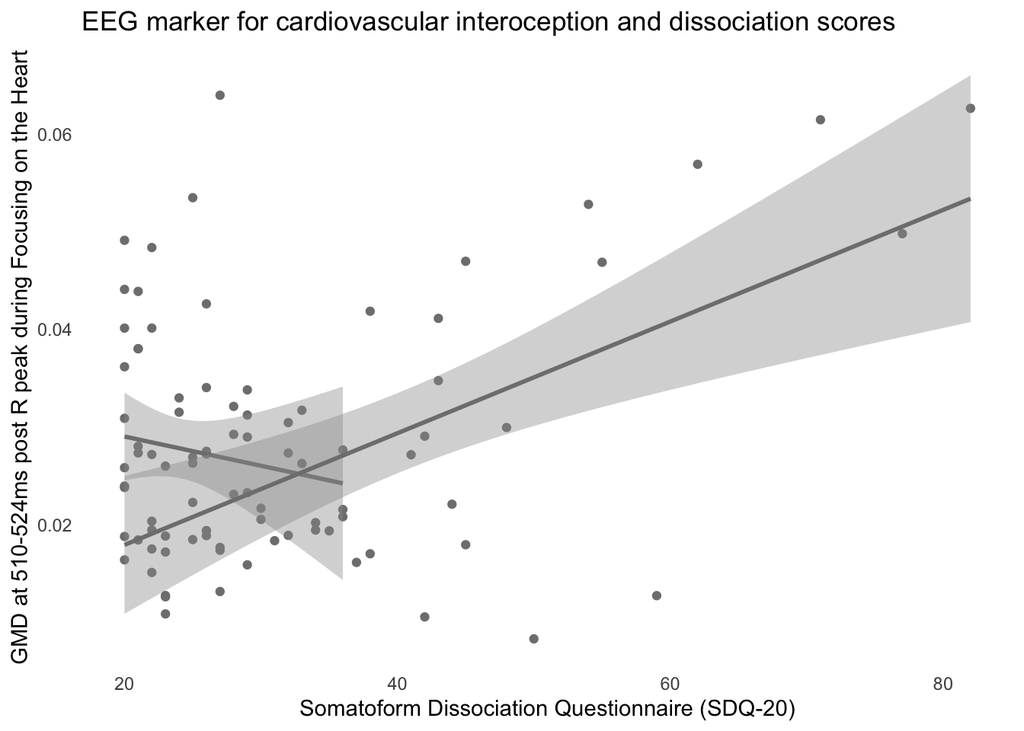

```r
# Visulization of GMD_HEART_510 and SDQ
GMD_HEART_510_sdq<- ggplot(df, aes(x = sdq, y = GMD_HEART_510, color = as.factor(group))) +
  geom_point() +
  geom_smooth(method = "lm", se = TRUE) +
  labs(x = "Somatoform Dissociation Questionnaire (SDQ-20)",
       y = "GMD at 510-524ms post R peak during Focusing on the Heart",
       title = "EEG marker for cardiovascular interoception and dissociation scores",
       color = "Group") +
 theme_minimal() +
  theme(panel.grid = element_blank()) +  # Remove gridlines
  scale_color_manual(values = c("FND" = "#E95248", "HC" = "#868686FF"))
GMD_HEART_510_sdq
```

```r
    pdf("5.2_Plot_GMD_heart510_sdq.pdf")
    GMD_HEART_510_sdq
    dev.off()
```

```r
df$GFP_SOUND_285
```

[output not shown]

```r
GFP_HEART_285_SFMDRS <- cor.test(df_sfmdrs$GFP_HEART_285, df_sfmdrs$sfmdrs, method = "pearson")
GFP_HEART_285_SFMDRS
```

```
    Pearson's product-moment correlation

data:  df_sfmdrs$GFP_HEART_285 and df_sfmdrs$sfmdrs
t = -0.14247, df = 38, p-value = 0.8875
alternative hypothesis: true correlation is not equal to 0
95 percent confidence interval:
 -0.3322242  0.2904942
sample estimates:
        cor
-0.02310609
```

```r
GFP_HEART_285_CGI <- cor.test(df_FND$GFP_HEART_285, df_FND$cgi, method = "pearson")
GFP_HEART_285_CGI
```

```
    Pearson's product-moment correlation

data:  df_FND$GFP_HEART_285 and df_FND$cgi
t = 0.63061, df = 38, p-value = 0.5321
alternative hypothesis: true correlation is not equal to 0
95 percent confidence interval:
 -0.2166084  0.4005782
sample estimates:
      cor
0.1017678
```

```r
GFP_HEART_285_SDQ <- cor.test(df_FND$GFP_HEART_285, df_FND$sdq, method = "pearson")
GFP_HEART_285_SDQ
```

```
    Pearson's product-moment correlation

data:  df_FND$GFP_HEART_285 and df_FND$sdq
t = 0.044064, df = 38, p-value = 0.9651
alternative hypothesis: true correlation is not equal to 0
95 percent confidence interval:
 -0.3050407  0.3179493
sample estimates:
        cor
0.007147912
```

```r
GFP_HEART_285_pos <- cor.test(df_FND$GFP_HEART_285, df_FND$sum_positive_signs, method = "pearson")
GFP_HEART_285_pos
```

```
    Pearson's product-moment correlation

data:  df_FND$GFP_HEART_285 and df_FND$sum_positive_signs
t = 0.90845, df = 38, p-value = 0.3694
alternative hypothesis: true correlation is not equal to 0
95 percent confidence interval:
 -0.1735982  0.4374378
sample estimates:
      cor
0.1457954
```

```r
# Extract p-values
p_values <- c(GFP_HEART_285_SFMDRS$p.value, GFP_HEART_285_CGI$p.value,
              GFP_HEART_285_SDQ$p.value, GFP_HEART_285_pos$p.value)
# Apply FDR correction
p_values_fdr <- p.adjust(p_values, method = "fdr")
# Display corrected p-values
p_values_fdr
```

```
[1] 0.9650843 0.9650843 0.9650843 0.9650843
```

```r
F1_HEART_185_SFMDRS <- cor.test(df_sfmdrs$F1_HEART_185, df_sfmdrs$sfmdrs, method = "pearson")
F1_HEART_185_SFMDRS
```

```
    Pearson's product-moment correlation

data:  df_sfmdrs$F1_HEART_185 and df_sfmdrs$sfmdrs
t = -1.2323, df = 38, p-value = 0.2254
alternative hypothesis: true correlation is not equal to 0
95 percent confidence interval:
 -0.4783336  0.1229851
sample estimates:
       cor
-0.1960345
```

```r
F1_HEART_185_CGI <- cor.test(df_FND$F1_HEART_185, df_FND$cgi, method = "pearson")
F1_HEART_185_CGI
```

```
    Pearson's product-moment correlation

data:  df_FND$F1_HEART_185 and df_FND$cgi
t = -0.38373, df = 38, p-value = 0.7033
alternative hypothesis: true correlation is not equal to 0
95 percent confidence interval:
 -0.3665439  0.2543025
sample estimates:
        cor
-0.06212847
```

```r
F1_HEART_185_SDQ <- cor.test(df_FND$F1_HEART_185, df_FND$sdq, method = "pearson")
F1_HEART_185_SDQ
```

```
    Pearson's product-moment correlation

data:  df_FND$F1_HEART_185 and df_FND$sdq
t = 0.23675, df = 38, p-value = 0.8141
alternative hypothesis: true correlation is not equal to 0
95 percent confidence interval:
 -0.2764363  0.3457537
sample estimates:
      cor
0.0383779
```

```r
F1_HEART_185_pos <- cor.test(df_FND$F1_HEART_185, df_FND$sum_positive_signs, method = "pearson")
F1_HEART_185_pos
```

```
    Pearson's product-moment correlation

data:  df_FND$F1_HEART_185 and df_FND$sum_positive_signs
t = -0.34765, df = 38, p-value = 0.73
alternative hypothesis: true correlation is not equal to 0
95 percent confidence interval:
 -0.3614752  0.2597594
sample estimates:
        cor
-0.05630605
```

```r
# Extract p-values
p_values <- c(F1_HEART_185_SFMDRS$p.value, F1_HEART_185_CGI$p.value,
              F1_HEART_185_SDQ$p.value, F1_HEART_185_pos$p.value)
# Apply FDR correction
p_values_fdr <- p.adjust(p_values, method = "fdr")
# Display corrected p-values
p_values_fdr
```

```
[1] 0.8141211 0.8141211 0.8141211 0.8141211
```

Visualization GFP plot

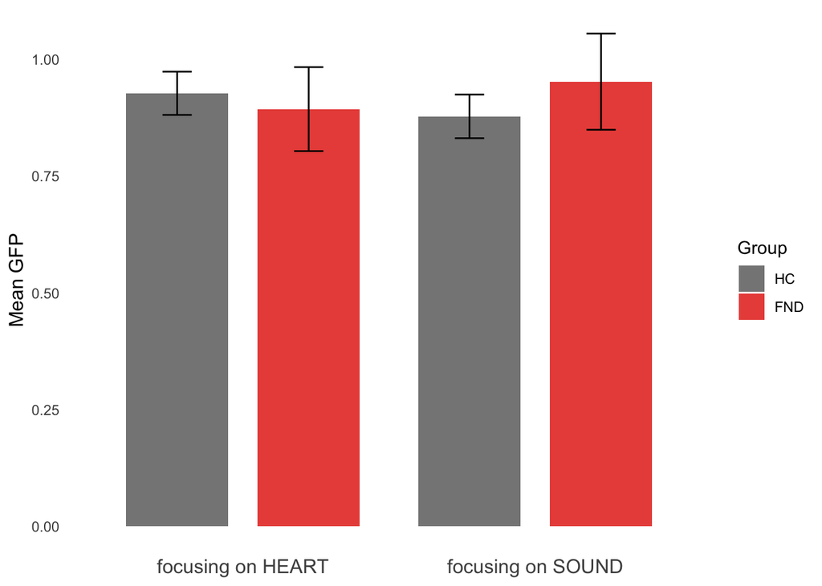

```r
# Reshape to long format
df_gfp_plot <- df %>%
  select(pcode, group, GFP_HEART_285, GFP_SOUND_285) %>%
  pivot_longer(cols = c(GFP_HEART_285, GFP_SOUND_285),
               names_to = "Condition",
               values_to = "Value")
df_gfp_plot <- df_gfp_plot %>%
  mutate(group = factor(group, levels = c(0, 1), labels = c("HC", "FND")))

# Calulate mean and se
summary_df <- df_gfp_plot %>%
  group_by(group, Condition) %>%
  dplyr::summarise(
    mean = mean(Value, na.rm = TRUE),
    se = sd(Value, na.rm = TRUE) / sqrt(n()),
    .groups = "drop")

# group colors
group_colors <- c("FND" = "#E95248", "HC" = "#868686FF")

# Relabel conditions for x-axis
summary_df <- summary_df %>%
  mutate(Condition = case_when(
    Condition == "GFP_HEART_285" ~ "focusing on HEART",
    Condition == "GFP_SOUND_285" ~ "focusing on SOUND",
    TRUE ~ as.character(Condition)))

#  bar plot with SE error bars
ggplot(summary_df, aes(x = Condition, y = mean, fill = group)) +
  geom_bar(stat = "identity", position = position_dodge(0.9), width = 0.7) +
  geom_errorbar(aes(ymin = mean - se, ymax = mean + se),
                position = position_dodge(0.9), width = 0.2) +
  scale_fill_manual(values = group_colors) +
  expand_limits(y = 0.5) +  # Soft lower limit, won't cut off bars
  labs(y = "Mean GFP", x = NULL, fill = "Group") +
  theme_minimal() +
  theme( panel.grid = element_blank(),
    axis.text.x = element_text(size = 12),
    axis.title.y = element_text(size = 12),
    legend.position = "right")
```